# 04. Mock community validation

```r
# 분석에 사용하는 패키지와 공통 함수를 불러온다.
source("./load_packages.R")
source("./functions.R")

package_dir <- normalizePath("../../decontamSensitivity", winslash = "/")
devtools::load_all(package_dir, quiet = TRUE)

input_path <- "./Phyloseq/phy_F270R210_260921.rds"
results_dir <- "./Results"
dir.create(results_dir, showWarnings = FALSE)

thresholds <- c(0.01, 0.05, seq(0.1, 0.9, by = 0.1))
methods <- c("prevalence", "frequency")
control_scenarios <- "prep_control_only"

scenario_label <- c(
  prep_control_only = "Prep control only",
  air_swab_only = "Air Swab only",
  prep_and_air_swab = "Prep control + Air Swab"
)

method_label <- c(
  prevalence = "Prevalence",
  frequency = "Frequency"
)
```

# 1 1) Mock community and reference profiles

## 1.1 MSA-2005 theoretical composition

```r
# 제공된 MSA-2005 균주를 Genus 수준의 균등 조성으로 정의한다.
mock_truth <- tibble::tribble(
  ~Genus, ~Species, ~ATCC, ~expected_abundance,
  "Acinetobacter", "Acinetobacter johnsonii", "ATCC 17909", 1 / 6,
  "Corynebacterium", "Corynebacterium striatum", "ATCC 6940", 1 / 6,
  "Micrococcus", "Micrococcus luteus", "ATCC 4698", 1 / 6,
  "Cutibacterium", "Cutibacterium acnes", "ATCC 11828", 1 / 6,
  "Staphylococcus", "Staphylococcus epidermidis", "ATCC 12228", 1 / 6,
  "Streptococcus", "Streptococcus mitis", "ATCC 49456", 1 / 6
)

readr::write_csv(
  mock_truth,
  file.path(results_dir, "04_MSA2005_theoretical_composition.csv")
)

knitr::kable(mock_truth, digits = 4)
```

| Genus | Species | ATCC | expected_abundance |
| --- | --- | --- | --- |
| Acinetobacter | Acinetobacter johnsonii | ATCC 17909 | 0.1667 |
| Corynebacterium | Corynebacterium striatum | ATCC 6940 | 0.1667 |
| Micrococcus | Micrococcus luteus | ATCC 4698 | 0.1667 |
| Cutibacterium | Cutibacterium acnes | ATCC 11828 | 0.1667 |
| Staphylococcus | Staphylococcus epidermidis | ATCC 12228 | 0.1667 |
| Streptococcus | Streptococcus mitis | ATCC 49456 | 0.1667 |

## 1.2 Sample assignment

```r
phy <- readRDS(input_path)

metadata <- data.frame(sample_data(phy), check.names = FALSE) |>
  tibble::rownames_to_column("SampleID") |>
  dplyr::mutate(
    Cycle = sub("\\.0$", "", as.character(Cycle)),
    is_prep_control = !is.na(control_type) & control_type == "Prep control",
    is_air_swab = !is.na(control_type) & control_type == "Air Swab",
    is_cell_mock = !is.na(control_type) & control_type == "Cell_mix",
    is_dna_mock = !is.na(control_type) & control_type == "DNA_mix",
    is_positive_control = !is.na(Sample_Control) & Sample_Control == "PC",
    is_true = !is_prep_control & !is_air_swab & !is_positive_control,
    concentration_raw = as.numeric(DNA_ng_uL)
  )

zero_replacement <- min(
  metadata$concentration_raw[metadata$concentration_raw > 0],
  na.rm = TRUE
) / 2

metadata <- metadata |>
  dplyr::mutate(
    decontam_concentration = dplyr::if_else(
      concentration_raw == 0,
      zero_replacement,
      concentration_raw
    )
  )

phy_metadata <- metadata |>
  tibble::column_to_rownames("SampleID")
sample_data(phy) <- sample_data(phy_metadata)

cell_mock_ids <- metadata |>
  dplyr::filter(is_cell_mock, Cycle == "3") |>
  dplyr::pull(SampleID)

dna_mock_id <- metadata |>
  dplyr::filter(is_dna_mock) |>
  dplyr::pull(SampleID)

mock_sample_table <- metadata |>
  dplyr::filter(is_cell_mock | is_dna_mock) |>
  dplyr::select(
    SampleID,
    Subject,
    Cycle,
    control_type,
    DNA_ng_uL,
    Mol_Conc_nM,
    Total_uL
  )

readr::write_csv(
  mock_sample_table,
  file.path(results_dir, "04_mock_sample_assignment.csv")
)

knitr::kable(mock_sample_table, digits = 3)
```

| SampleID | Subject | Cycle | control_type | DNA_ng_uL | Mol_Conc_nM | Total_uL |
| --- | --- | --- | --- | --- | --- | --- |
| 70_S70_L001 | Cell-Mock | 3 | Cell_mix | 9.20 | 22.161 | 27.701 |
| 71_S71_L001 | Cell-Mock-1 | 3 | Cell_mix | 10.80 | 26.015 | 32.519 |
| 72_S72_L001 | Cell-Mock-2 | 3 | Cell_mix | 13.30 | 32.037 | 40.047 |
| 73_S73_L001 | DNA-Mock | - | DNA_mix | 9.98 | 24.040 | 30.050 |

The Cell mock has three Cycle 3 replicates. The DNA mock was sequenced in the same run and is used as an observed reference. Because two target organisms are not consistently resolved to Species in the taxonomy table, accuracy is evaluated at Genus level.

## 1.3 Raw mock profiles

```r
count_table <- as(otu_table(phy), "matrix")
if (taxa_are_rows(phy)) {
  count_table <- t(count_table)
}

taxonomy <- data.frame(tax_table(phy), check.names = FALSE) |>
  tibble::rownames_to_column("feature_id") |>
  dplyr::mutate(
    Genus = dplyr::if_else(
      is.na(Genus) | Genus == "",
      "Unclassified",
      as.character(Genus)
    )
  )

genus_by_asv <- taxonomy$Genus[match(colnames(count_table), taxonomy$feature_id)]
names(genus_by_asv) <- colnames(count_table)
```

```r
# Raw와 decontam 결과에서 반복하여 사용하는 Genus profile을 계산한다.
make_genus_profile <- function(sample_id, removed_asv = character()) {
  sample_count <- count_table[sample_id, ]
  sample_count[names(sample_count) %in% removed_asv] <- 0

  genus_count <- rowsum(
    matrix(sample_count, ncol = 1),
    group = genus_by_asv[names(sample_count)],
    reorder = FALSE
  )[, 1]

  tibble::tibble(
    SampleID = sample_id,
    Genus = names(genus_count),
    count = as.numeric(genus_count),
    relative_abundance = if (sum(genus_count) > 0) {
      as.numeric(genus_count) / sum(genus_count)
    } else {
      rep(0, length(genus_count))
    }
  )
}
```

```r
raw_cell_list <- vector("list", length(cell_mock_ids))
for (i in seq_along(cell_mock_ids)) {
  raw_cell_list[[i]] <- make_genus_profile(cell_mock_ids[i])
}
raw_cell_profile <- dplyr::bind_rows(raw_cell_list)

dna_mock_profile <- make_genus_profile(dna_mock_id) |>
  dplyr::select(Genus, dna_mock_abundance = relative_abundance)

# Cell mix 3개를 평균 내지 않고 각각의 raw profile로 유지한다.
raw_mock_sample_label <- metadata |>
  dplyr::filter(SampleID %in% c(cell_mock_ids, dna_mock_id)) |>
  dplyr::select(SampleID, Subject)

reference_composition <- dplyr::bind_rows(
  mock_truth |>
    dplyr::transmute(
      reference = "Theoretical",
      Genus,
      relative_abundance = expected_abundance
    ),
  dna_mock_profile |>
    dplyr::transmute(
      reference = "DNA-Mock",
      Genus,
      relative_abundance = dna_mock_abundance
    ),
  raw_cell_profile |>
    dplyr::left_join(raw_mock_sample_label, by = "SampleID") |>
    dplyr::transmute(
      reference = Subject,
      Genus,
      relative_abundance
    )
) |>
  dplyr::mutate(
    reference = factor(
      reference,
      levels = c(
        "Theoretical",
        metadata$Subject[match(cell_mock_ids, metadata$SampleID)],
        metadata$Subject[match(dna_mock_id, metadata$SampleID)]
      )
    )
  ) |>
  dplyr::arrange(reference, dplyr::desc(relative_abundance))

readr::write_csv(
  reference_composition,
  file.path(results_dir, "04_reference_composition_by_mock_sample.csv")
)

reference_composition |>
  dplyr::filter(relative_abundance >= 0.001) |>
  tidyr::pivot_wider(
    names_from = reference,
    values_from = relative_abundance,
    values_fill = 0
  ) |>
  knitr::kable(digits = 4)
```

| Genus | Theoretical | Cell-Mock | Cell-Mock-1 | Cell-Mock-2 | DNA-Mock |
| --- | --- | --- | --- | --- | --- |
| Acinetobacter | 0.1667 | 0.6515 | 0.7099 | 0.7211 | 0.3102 |
| Corynebacterium | 0.1667 | 0.1424 | 0.0741 | 0.0609 | 0.1446 |
| Micrococcus | 0.1667 | 0.0661 | 0.1104 | 0.1063 | 0.0024 |
| Cutibacterium | 0.1667 | 0.0039 | 0.0031 | 0.0025 | 0.0251 |
| Staphylococcus | 0.1667 | 0.0068 | 0.0138 | 0.0076 | 0.2710 |
| Streptococcus | 0.1667 | 0.0194 | 0.0544 | 0.0378 | 0.1719 |
| Bacteroides_H_857956 | 0.0000 | 0.0152 | 0.0000 | 0.0022 | 0.0000 |
| Unclassified | 0.0000 | 0.0140 | 0.0045 | 0.0240 | 0.0224 |
| COE1 | 0.0000 | 0.0129 | 0.0032 | 0.0055 | 0.0020 |
| UBA3282 | 0.0000 | 0.0116 | 0.0000 | 0.0000 | 0.0016 |
| Pelethenecus | 0.0000 | 0.0096 | 0.0000 | 0.0000 | 0.0000 |
| Duncaniella | 0.0000 | 0.0039 | 0.0037 | 0.0077 | 0.0108 |
| Schaedlerella | 0.0000 | 0.0037 | 0.0000 | 0.0014 | 0.0000 |
| Paramuribaculum | 0.0000 | 0.0034 | 0.0058 | 0.0047 | 0.0112 |
| G11 | 0.0000 | 0.0030 | 0.0010 | 0.0000 | 0.0000 |
| Ruminococcus_B | 0.0000 | 0.0023 | 0.0000 | 0.0000 | 0.0000 |
| Ligilactobacillus | 0.0000 | 0.0022 | 0.0000 | 0.0000 | 0.0000 |
| Limosilactobacillus | 0.0000 | 0.0019 | 0.0000 | 0.0000 | 0.0016 |
| Sporofaciens | 0.0000 | 0.0018 | 0.0000 | 0.0000 | 0.0000 |
| Alistipes_A_871400 | 0.0000 | 0.0015 | 0.0000 | 0.0000 | 0.0000 |
| Lactobacillus | 0.0000 | 0.0014 | 0.0047 | 0.0015 | 0.0113 |
| Lawsonibacter | 0.0000 | 0.0014 | 0.0000 | 0.0000 | 0.0000 |
| Petralouisia | 0.0000 | 0.0014 | 0.0000 | 0.0000 | 0.0000 |
| Lepagella | 0.0000 | 0.0013 | 0.0012 | 0.0014 | 0.0013 |
| Eubacterium_F | 0.0000 | 0.0013 | 0.0000 | 0.0000 | 0.0000 |
| Prevotella | 0.0000 | 0.0012 | 0.0000 | 0.0000 | 0.0000 |
| Caccoplasma | 0.0000 | 0.0012 | 0.0000 | 0.0000 | 0.0000 |
| Enterenecus | 0.0000 | 0.0010 | 0.0000 | 0.0000 | 0.0000 |
| Muribaculum | 0.0000 | 0.0000 | 0.0015 | 0.0000 | 0.0000 |
| Phocaeicola_A | 0.0000 | 0.0000 | 0.0000 | 0.0024 | 0.0019 |
| UBA3263 | 0.0000 | 0.0000 | 0.0000 | 0.0024 | 0.0000 |
| UBA7173 | 0.0000 | 0.0000 | 0.0000 | 0.0013 | 0.0015 |
| Akkermansia | 0.0000 | 0.0000 | 0.0000 | 0.0000 | 0.0014 |
| JAGBWK01 | 0.0000 | 0.0000 | 0.0000 | 0.0000 | 0.0011 |

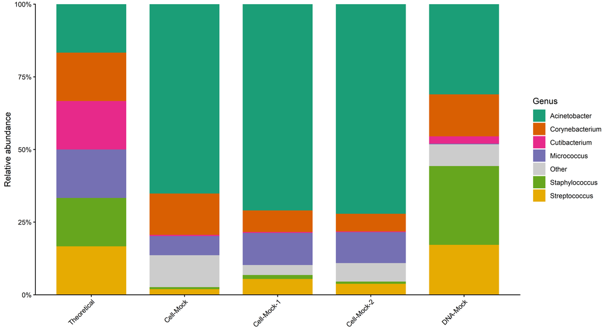

```r
target_genera <- mock_truth$Genus

reference_plot_data <- reference_composition |>
  dplyr::mutate(
    Genus_plot = dplyr::if_else(Genus %in% target_genera, Genus, "Other")
  ) |>
  dplyr::group_by(reference, Genus_plot) |>
  dplyr::summarise(
    relative_abundance = sum(relative_abundance),
    .groups = "drop"
  )

mock_taxa_color <- c(
  "Acinetobacter" = "#1B9E77",
  "Corynebacterium" = "#D95F02",
  "Micrococcus" = "#7570B3",
  "Cutibacterium" = "#E7298A",
  "Staphylococcus" = "#66A61E",
  "Streptococcus" = "#E6AB02",
  "Other" = "grey80"
)

reference_composition_plot <- ggplot(
  reference_plot_data,
  aes(x = reference, y = relative_abundance, fill = Genus_plot)
) +
  geom_col(width = 0.75) +
  scale_fill_manual(values = mock_taxa_color) +
  scale_y_continuous(labels = scales::label_percent(), expand = c(0, 0)) +
  labs(x = NULL, y = "Relative abundance", fill = "Genus") +
  theme_classic() +
  theme(
    axis.text.x = element_text(angle = 45, hjust = 1),
    legend.position = "right"
  )

ggsave(
  file.path(results_dir, "04_reference_composition.png"),
  reference_composition_plot,
  width = 11,
  height = 6,
  dpi = 300
)

reference_composition_plot
```

# 2 2) Distribution of DNA mix off target ASVs across the sequencing run

Because the DNA mix entered at the library preparation stage, non target ASVs detected in this sample are examined across all other samples. Widespread detection and a positive relationship between DNA mix counts and pooled counts from other libraries would be consistent with sample to sample cross talk, although this pattern cannot distinguish library preparation carryover from sequencing index misassignment.

```r
sample_role_table <- metadata |>
  dplyr::mutate(
    sample_role = dplyr::case_when(
      is_true ~ "True",
      is_prep_control ~ "Prep control",
      is_air_swab ~ "Air Swab",
      is_cell_mock ~ "Cell mix",
      is_dna_mock ~ "DNA mix",
      TRUE ~ "Other"
    )
  ) |>
  dplyr::select(SampleID, sample_role)

dna_off_target_asv <- taxonomy |>
  dplyr::filter(!Genus %in% target_genera) |>
  dplyr::filter(count_table[dna_mock_id, feature_id] > 0) |>
  dplyr::pull(feature_id)

other_sample_ids <- setdiff(rownames(count_table), dna_mock_id)
other_count <- count_table[
  other_sample_ids,
  dna_off_target_asv,
  drop = FALSE
]
other_relative_abundance <- sweep(
  other_count,
  1,
  rowSums(count_table[other_sample_ids, , drop = FALSE]),
  "/"
)

top_source_index <- apply(other_count, 2, which.max)
top_source_id <- rownames(other_count)[top_source_index]

dna_off_target_summary <- tibble::tibble(
  feature_id = dna_off_target_asv,
  dna_mix_reads = as.numeric(
    count_table[dna_mock_id, dna_off_target_asv]
  ),
  dna_mix_relative_abundance = dna_mix_reads / sum(
    count_table[dna_mock_id, ]
  ),
  pooled_other_reads = colSums(other_count),
  other_sample_prevalence = colMeans(other_count > 0),
  top_source_sample = top_source_id,
  top_source_reads = apply(other_count, 2, max)
) |>
  dplyr::left_join(
    sample_role_table |>
      dplyr::rename(
        top_source_sample = SampleID,
        top_source_role = sample_role
      ),
    by = "top_source_sample"
  ) |>
  dplyr::left_join(taxonomy, by = "feature_id") |>
  dplyr::mutate(
    dna_share_of_all_reads = dna_mix_reads /
      (dna_mix_reads + pooled_other_reads),
    detected_elsewhere = pooled_other_reads > 0,
    taxon_label = dplyr::case_when(
      !is.na(Species) & Species != "" ~ Species,
      !is.na(Genus) & Genus != "Unclassified" ~ paste0(Genus, " sp."),
      !is.na(Family) & Family != "" ~ paste0(Family, " sp."),
      TRUE ~ "Unclassified"
    ),
    ASV_label = paste0(taxon_label, " | ", substr(feature_id, 1, 8))
  ) |>
  dplyr::arrange(dplyr::desc(dna_mix_reads))

role_levels <- c("True", "Prep control", "Air Swab", "Cell mix", "Other")
role_summary_list <- vector("list", length(role_levels))

for (i in seq_along(role_levels)) {
  role_name <- role_levels[i]
  role_sample_ids <- sample_role_table |>
    dplyr::filter(sample_role == role_name) |>
    dplyr::pull(SampleID)

  role_sample_ids <- intersect(role_sample_ids, other_sample_ids)

  if (length(role_sample_ids) > 0) {
    role_count <- count_table[
      role_sample_ids,
      dna_off_target_asv,
      drop = FALSE
    ]

    role_relative_abundance <- sweep(
      role_count,
      1,
      rowSums(count_table[role_sample_ids, , drop = FALSE]),
      "/"
    )

    role_summary_list[[i]] <- tibble::tibble(
      feature_id = dna_off_target_asv,
      sample_role = role_name,
      n_samples = length(role_sample_ids),
      detected_samples = colSums(role_count > 0),
      prevalence = detected_samples / n_samples,
      total_reads = colSums(role_count),
      mean_relative_abundance = colMeans(role_relative_abundance)
    )
  }
}

dna_off_target_role_summary <- dplyr::bind_rows(role_summary_list) |>
  dplyr::left_join(
    dna_off_target_summary |>
      dplyr::select(feature_id, taxon_label, ASV_label, dna_mix_reads),
    by = "feature_id"
  ) |>
  dplyr::mutate(
    sample_role = factor(sample_role, levels = role_levels)
  )

true_sample_ids_for_dna <- sample_role_table |>
  dplyr::filter(sample_role == "True") |>
  dplyr::pull(SampleID)

dna_off_target_in_true <- colSums(
  count_table[
    true_sample_ids_for_dna,
    dna_off_target_asv,
    drop = FALSE
  ]
) > 0

dna_off_target_run_summary <- tibble::tibble(
  metric = c(
    "DNA mix total reads",
    "DNA mix off target reads",
    "DNA mix off target read percentage",
    "DNA mix off target ASVs",
    "Off target ASVs detected in other samples",
    "Off target reads represented by ASVs detected elsewhere (%)",
    "Off target ASVs detected in True samples",
    "Off target reads represented by ASVs detected in True samples (%)",
    "Spearman rho: DNA mix reads versus pooled other sample reads"
  ),
  value = c(
    sum(count_table[dna_mock_id, ]),
    sum(count_table[dna_mock_id, dna_off_target_asv]),
    100 * sum(count_table[dna_mock_id, dna_off_target_asv]) /
      sum(count_table[dna_mock_id, ]),
    length(dna_off_target_asv),
    sum(dna_off_target_summary$detected_elsewhere),
    100 * sum(
      dna_off_target_summary$dna_mix_reads[
        dna_off_target_summary$detected_elsewhere
      ]
    ) / sum(dna_off_target_summary$dna_mix_reads),
    sum(dna_off_target_in_true),
    100 * sum(
      dna_off_target_summary$dna_mix_reads[dna_off_target_in_true]
    ) / sum(dna_off_target_summary$dna_mix_reads),
    stats::cor(
      dna_off_target_summary$dna_mix_reads,
      dna_off_target_summary$pooled_other_reads,
      method = "spearman"
    )
  )
)

readr::write_csv(
  dna_off_target_summary,
  file.path(results_dir, "04_DNA_mix_off_target_ASV_run_distribution.csv")
)
readr::write_csv(
  dna_off_target_role_summary,
  file.path(results_dir, "04_DNA_mix_off_target_ASV_by_sample_role.csv")
)

dna_off_target_run_summary |>
  knitr::kable(digits = 3)
```

| metric | value |
| --- | --- |
| DNA mix total reads | 52189.000 |
| DNA mix off target reads | 3899.000 |
| DNA mix off target read percentage | 7.471 |
| DNA mix off target ASVs | 87.000 |
| Off target ASVs detected in other samples | 77.000 |
| Off target reads represented by ASVs detected elsewhere (%) | 97.743 |
| Off target ASVs detected in True samples | 75.000 |
| Off target reads represented by ASVs detected in True samples (%) | 65.863 |
| Spearman rho: DNA mix reads versus pooled other sample reads | 0.583 |

```r
dna_off_target_summary |>
  dplyr::select(
    feature_id,
    taxon_label,
    dna_mix_reads,
    dna_mix_relative_abundance,
    pooled_other_reads,
    other_sample_prevalence,
    top_source_sample,
    top_source_role,
    top_source_reads
  ) |>
  dplyr::slice_head(n = 30) |>
  knitr::kable(digits = 4)
```

| feature_id | taxon_label | dna_mix_reads | dna_mix_relative_abundance | pooled_other_reads | other_sample_prevalence | top_source_sample | top_source_role | top_source_reads |
| --- | --- | --- | --- | --- | --- | --- | --- | --- |
| b6c1a8ba78f65c4a4e96627ccc53ac86 | Lactobacillus johnsonii | 589 | 0.0113 | 28213 | 0.9028 | 44_S44_L001 | True | 3695 |
| acc18bd166c367b52d66b8300fe75431 | Muribaculaceae sp. | 278 | 0.0053 | 954 | 0.1667 | 5_S5_L001 | True | 225 |
| 17a6531a5ea2f2f5b0275eaf27a92ad4 | Muribaculaceae sp. | 174 | 0.0033 | 626 | 0.1667 | 67_S67_L001 | True | 118 |
| 45ac4dd5ac6a33903b3fae14faff2115 | Duncaniella muricolitica | 171 | 0.0033 | 526 | 0.2361 | 68_S68_L001 | True | 125 |
| f8a935b0e4e5d19f4377693f05e0655c | Paramuribaculum sp000431155 | 127 | 0.0024 | 192 | 0.0694 | 67_S67_L001 | True | 77 |
| 952c1fdc4c8295d4742b25f65e8c514a | Paramuribaculum sp000431155 | 99 | 0.0019 | 1852 | 0.5139 | 55_S55_L001 | True | 263 |
| f49b6dab9667b7929bb08a81b4d58ab1 | Phocaeicola_A sartorii | 98 | 0.0019 | 21394 | 0.7361 | 46_S46_L001 | True | 1943 |
| e34c310526af4a643e430225516a801f | Muribaculaceae sp. | 97 | 0.0019 | 205 | 0.0833 | 67_S67_L001 | True | 71 |
| 72bc22315544a201ede9dec6af150e98 | Duncaniella muricolitica | 88 | 0.0017 | 175 | 0.0556 | 67_S67_L001 | True | 65 |
| 838d0736efd9295506133747708054b9 | Paramuribaculum sp000431155 | 85 | 0.0016 | 131 | 0.0417 | 67_S67_L001 | True | 51 |
| 3f698d215495900c36d9f6abc189b2d0 | Duncaniella muricolitica | 85 | 0.0016 | 151 | 0.0556 | 67_S67_L001 | True | 69 |
| a47b4dc7cfdd15e4a610732ce5d2a494 | Muribaculaceae sp. | 82 | 0.0016 | 1461 | 0.2222 | 7_S7_L001 | True | 367 |
| dd9975e5852a9d896371876b67b909d8 | Muribaculaceae sp. | 80 | 0.0015 | 171 | 0.0694 | 67_S67_L001 | True | 53 |
| b21bbd9f9a9ee207b793d76c06672371 | Paramuribaculum sp000431155 | 79 | 0.0015 | 2378 | 0.7361 | 26_S26_L001 | Prep control | 247 |
| 7966f669971b26c2d74342a85e4c3880 | UBA3282 sp003611805 | 74 | 0.0014 | 170 | 0.0278 | 68_S68_L001 | True | 143 |
| baab695bd57246eb38ec8cbe91b87b20 | Duncaniella dubosii | 72 | 0.0014 | 284 | 0.0694 | 68_S68_L001 | True | 101 |
| dfa833b266bd2993b86feab3617b34c3 | Akkermansia muciniphila_D_776786 | 71 | 0.0014 | 1435 | 0.3889 | 62_S62_L001 | True | 285 |
| 531ab4c63ec669ee00972774562309de | Duncaniella muris | 71 | 0.0014 | 530 | 0.2778 | 3_S3_L001 | Prep control | 90 |
| a2219a9d615b767a7a93a2d7973dcc69 | Muribaculaceae sp. | 66 | 0.0013 | 1959 | 0.5694 | 34_S34_L001 | True | 145 |
| e41375bd06424fdf1659448e6416bfd2 | Lachnospiraceae sp. | 64 | 0.0012 | 1121 | 0.0694 | 68_S68_L001 | True | 471 |
| 2c223e3a0277fd046670994cede83dec | Muribaculaceae sp. | 62 | 0.0012 | 403 | 0.1111 | 1_S1_L001 | Prep control | 89 |
| 2893aeb225744a49866e347886550112 | Lepagella muris_A | 59 | 0.0011 | 541 | 0.2639 | 29_S29_L001 | True | 81 |
| 74b35ae658465e7512c2b61f7906c907 | Paramuribaculum sp900551515 | 56 | 0.0011 | 2208 | 0.7083 | 35_S35_L001 | True | 154 |
| 5105f91b1b28ae7ee4dafb34c84c8fff | Paramuribaculum sp000431155 | 52 | 0.0010 | 1172 | 0.3333 | 55_S55_L001 | True | 211 |
| 36e7d485787d726a0e16bff74100463e | UBA3263 sp001689615 | 50 | 0.0010 | 2525 | 0.7917 | 43_S43_L001 | Air Swab | 226 |
| e94a9da4bdf2d1d6fd8b6216ea53a5ab | Limosilactobacillus sp. | 49 | 0.0009 | 3695 | 0.5972 | 51_S51_L001 | Prep control | 615 |
| d33d84f90d2924040cf2eb66c7abe2fc | Ligilactobacillus sp. | 45 | 0.0009 | 5885 | 0.9028 | 13_S13_L001 | True | 728 |
| faf4d01b3063b5e3eaddffb26c221250 | Muribaculum gordoncarteri | 45 | 0.0009 | 274 | 0.0833 | 4_S4_L001 | Air Swab | 68 |
| 38ed7202efb87e3468f28422c76f6a86 | Duncaniella muris | 42 | 0.0008 | 344 | 0.1806 | 1_S1_L001 | Prep control | 58 |
| 42690539aa399c812b99bc18ad34b6b7 | UBA7173 sp900540205 | 40 | 0.0008 | 3035 | 0.9028 | 24_S24_L001 | True | 198 |

```r
dna_cross_talk_plot <- ggplot(
  dna_off_target_summary,
  aes(
    x = pooled_other_reads + 1,
    y = dna_mix_reads + 1,
    color = top_source_role,
    size = other_sample_prevalence
  )
) +
  geom_point(alpha = 0.8) +
  ggrepel::geom_text_repel(
    data = dna_off_target_summary |>
      dplyr::slice_head(n = 12),
    aes(label = taxon_label),
    size = 3,
    max.overlaps = Inf,
    show.legend = FALSE
  ) +
  scale_x_log10(labels = scales::label_number()) +
  scale_y_log10(labels = scales::label_number()) +
  scale_color_manual(values = c(
    "True" = "#009E73",
    "Prep control" = "#0072B2",
    "Air Swab" = "#E69F00",
    "Cell mix" = "#CC79A7",
    "Other" = "grey55"
  )) +
  scale_size_continuous(labels = scales::label_percent()) +
  labs(
    x = "Pooled reads in all other samples (+1)",
    y = "DNA mix reads (+1)",
    color = "Largest source library",
    size = "Prevalence in other samples"
  ) +
  theme_classic()

ggsave(
  file.path(results_dir, "04_DNA_mix_off_target_cross_talk_scatter.png"),
  dna_cross_talk_plot,
  width = 11,
  height = 8,
  dpi = 300
)

dna_cross_talk_plot
```

[figure not shown]

```r
top_dna_off_target_asv <- dna_off_target_summary |>
  dplyr::slice_head(n = 30) |>
  dplyr::pull(feature_id)

dna_role_plot_data <- dna_off_target_role_summary |>
  dplyr::filter(feature_id %in% top_dna_off_target_asv) |>
  dplyr::mutate(
    ASV_label = factor(
      ASV_label,
      levels = rev(
        dna_off_target_summary$ASV_label[
          dna_off_target_summary$feature_id %in% top_dna_off_target_asv
        ]
      )
    )
  )

dna_role_distribution_plot <- ggplot(
  dna_role_plot_data,
  aes(
    x = sample_role,
    y = ASV_label,
    size = prevalence,
    fill = mean_relative_abundance
  )
) +
  geom_point(shape = 21, color = "grey25") +
  scale_size_continuous(
    range = c(1, 8),
    labels = scales::label_percent()
  ) +
  scale_fill_viridis_c(
    option = "C",
    trans = "sqrt",
    labels = scales::label_percent(accuracy = 0.01)
  ) +
  labs(
    x = NULL,
    y = NULL,
    size = "Sample prevalence",
    fill = "Mean relative abundance"
  ) +
  theme_classic() +
  theme(
    axis.text.x = element_text(angle = 30, hjust = 1),
    panel.grid.major = element_line(color = "grey90", linewidth = 0.3)
  )

ggsave(
  file.path(results_dir, "04_DNA_mix_off_target_distribution_by_role.png"),
  dna_role_distribution_plot,
  width = 13,
  height = 12,
  dpi = 300
)

dna_role_distribution_plot
```

[figure not shown]

# 3 3) ASVs increasing with serial dilution as candidate contaminants

Cell mix samples are ordered using the experimental serial dilution: Cell-Mock is undiluted, Cell-Mock-1 is diluted 1:10, and Cell-Mock-2 is diluted 1:100. `DNA_ng_uL` is the Qubit concentration measured after DNA extraction and is reported separately. Candidate contaminants are defined descriptively as off target ASVs whose relative abundance increases monotonically as the Cell mix is diluted. Detection in Cycle 3 Prep controls provides additional supporting evidence.

```r
# 실제 serial dilution 순서인 무희석, 1:10, 1:100으로 정렬한다.
cell_dilution <- metadata |>
  dplyr::filter(is_cell_mock) |>
  dplyr::mutate(
    dilution = dplyr::case_when(
      Subject == "Cell-Mock" ~ "Undiluted",
      Subject == "Cell-Mock-1" ~ "1:10",
      Subject == "Cell-Mock-2" ~ "1:100"
    ),
    dilution_factor = dplyr::case_when(
      dilution == "Undiluted" ~ 1,
      dilution == "1:10" ~ 10,
      dilution == "1:100" ~ 100
    ),
    dilution_level = factor(
      dilution,
      levels = c("Undiluted", "1:10", "1:100")
    ),
    Qubit_DNA_ng_uL = concentration_raw
  ) |>
  dplyr::arrange(dilution_factor) |>
  dplyr::select(
    SampleID,
    Subject,
    dilution,
    dilution_factor,
    dilution_level,
    Qubit_DNA_ng_uL
  )

cell_count <- count_table[cell_dilution$SampleID, , drop = FALSE]
cell_relative_abundance <- sweep(
  cell_count,
  1,
  rowSums(cell_count),
  "/"
)

# 희석 배수가 커질수록 상대풍부도가 단조 증가하는 ASV를 선별한다.
increasing_flag <- apply(
  cell_relative_abundance,
  2,
  function(x) all(diff(x) >= 0) && x[length(x)] > x[1]
)

prep_control_ids <- metadata |>
  dplyr::filter(Cycle == "3", is_prep_control) |>
  dplyr::pull(SampleID)

prep_control_reads <- colSums(
  count_table[prep_control_ids, , drop = FALSE]
)
prep_control_samples <- colSums(
  count_table[prep_control_ids, , drop = FALSE] > 0
)

increasing_asv_summary <- tibble::tibble(
  feature_id = colnames(cell_relative_abundance),
  relative_abundance_undiluted = cell_relative_abundance[1, ],
  relative_abundance_1_10 = cell_relative_abundance[2, ],
  relative_abundance_1_100 = cell_relative_abundance[3, ],
  increasing = increasing_flag,
  prep_control_reads = prep_control_reads[colnames(cell_relative_abundance)],
  prep_control_samples = prep_control_samples[colnames(cell_relative_abundance)]
) |>
  dplyr::filter(increasing) |>
  dplyr::left_join(taxonomy, by = "feature_id") |>
  dplyr::mutate(
    delta_relative_abundance = relative_abundance_1_100 - relative_abundance_undiluted,
    target_status = dplyr::if_else(
      Genus %in% target_genera,
      "Mock target",
      "Off target"
    ),
    detected_in_prep_control = dplyr::if_else(
      prep_control_reads > 0,
      "Yes",
      "No"
    ),
    taxon_label = dplyr::case_when(
      !is.na(Species) & Species != "" ~ Species,
      !is.na(Genus) & Genus != "Unclassified" ~ paste0(Genus, " sp."),
      !is.na(Family) & Family != "" ~ paste0(Family, " sp."),
      TRUE ~ "Unclassified"
    )
  ) |>
  dplyr::arrange(dplyr::desc(delta_relative_abundance))

dilution_candidate_asv <- increasing_asv_summary |>
  dplyr::filter(target_status == "Off target") |>
  dplyr::mutate(
    candidate_evidence = dplyr::if_else(
      detected_in_prep_control == "Yes",
      "Dilution increase + Prep control",
      "Dilution increase only"
    )
  )

readr::write_csv(
  increasing_asv_summary,
  file.path(results_dir, "04_cell_mix_increasing_ASV.csv")
)
readr::write_csv(
  dilution_candidate_asv,
  file.path(results_dir, "04_cell_mix_dilution_candidate_contaminant_ASV.csv")
)

cell_dilution |>
  knitr::kable(digits = 2)
```

| SampleID | Subject | dilution | dilution_factor | dilution_level | Qubit_DNA_ng_uL |
| --- | --- | --- | --- | --- | --- |
| 70_S70_L001 | Cell-Mock | Undiluted | 1 | Undiluted | 9.2 |
| 71_S71_L001 | Cell-Mock-1 | 1:10 | 10 | 1:10 | 10.8 |
| 72_S72_L001 | Cell-Mock-2 | 1:100 | 100 | 1:100 | 13.3 |

```r
dilution_candidate_asv |>
  dplyr::select(
    feature_id,
    taxon_label,
    relative_abundance_undiluted,
    relative_abundance_1_10,
    relative_abundance_1_100,
    delta_relative_abundance,
    detected_in_prep_control,
    prep_control_reads,
    prep_control_samples,
    candidate_evidence
  ) |>
  dplyr::slice_head(n = 30) |>
  knitr::kable(digits = 5)
```

| feature_id | taxon_label | relative_abundance_undiluted | relative_abundance_1_10 | relative_abundance_1_100 | delta_relative_abundance | detected_in_prep_control | prep_control_reads | prep_control_samples | candidate_evidence |
| --- | --- | --- | --- | --- | --- | --- | --- | --- | --- |
| 1be897ba1ae9fde0a82ba4d0c71f159b | Lachnospiraceae sp. | 0.00000 | 0.00000 | 0.00747 | 0.00747 | Yes | 7 | 1 | Dilution increase + Prep control |
| 11f677d62a3ec0969a65966eb7050c7f | Lachnospiraceae sp. | 0.00000 | 0.00000 | 0.00500 | 0.00500 | No | 0 | 0 | Dilution increase only |
| f49b6dab9667b7929bb08a81b4d58ab1 | Phocaeicola_A sartorii | 0.00000 | 0.00023 | 0.00242 | 0.00242 | Yes | 440 | 3 | Dilution increase + Prep control |
| d272bf25781448dde9031a24679a9012 | Bacteroides_H_857956 acidifaciens | 0.00000 | 0.00019 | 0.00212 | 0.00212 | Yes | 125 | 2 | Dilution increase + Prep control |
| 36e7d485787d726a0e16bff74100463e | UBA3263 sp001689615 | 0.00036 | 0.00066 | 0.00240 | 0.00203 | Yes | 44 | 3 | Dilution increase + Prep control |
| 45ac4dd5ac6a33903b3fae14faff2115 | Duncaniella muricolitica | 0.00000 | 0.00103 | 0.00197 | 0.00197 | No | 0 | 0 | Dilution increase only |
| baab695bd57246eb38ec8cbe91b87b20 | Duncaniella dubosii | 0.00000 | 0.00101 | 0.00172 | 0.00172 | No | 0 | 0 | Dilution increase only |
| db24050d1b1c55d82cc94544698c3670 | COE1 sp. | 0.00000 | 0.00099 | 0.00172 | 0.00172 | Yes | 16 | 1 | Dilution increase + Prep control |
| acc18bd166c367b52d66b8300fe75431 | Muribaculaceae sp. | 0.00000 | 0.00039 | 0.00164 | 0.00164 | No | 0 | 0 | Dilution increase only |
| a0ed3c259f6fceaaed3ef1b212339fb9 | Schaedlerella sp. | 0.00000 | 0.00000 | 0.00144 | 0.00144 | No | 0 | 0 | Dilution increase only |
| 08da1ecef85291c80c847e1cabf70b5e | Lachnospiraceae sp. | 0.00000 | 0.00000 | 0.00124 | 0.00124 | No | 0 | 0 | Dilution increase only |
| f8a935b0e4e5d19f4377693f05e0655c | Paramuribaculum sp000431155 | 0.00000 | 0.00043 | 0.00111 | 0.00111 | No | 0 | 0 | Dilution increase only |
| 81eb81acfe3c3b0fe1b0359689c88151 | COE1 sp000403215 | 0.00000 | 0.00029 | 0.00111 | 0.00111 | No | 0 | 0 | Dilution increase only |
| b20b8aa4bd244d965316a278875a1469 | Duncaniella dubosii | 0.00000 | 0.00000 | 0.00106 | 0.00106 | Yes | 4 | 1 | Dilution increase + Prep control |
| a2219a9d615b767a7a93a2d7973dcc69 | Muribaculaceae sp. | 0.00000 | 0.00021 | 0.00101 | 0.00101 | Yes | 27 | 1 | Dilution increase + Prep control |
| 064ad1ad889da847966bdb0600059b99 | UMGS1071 sp900548305 | 0.00000 | 0.00000 | 0.00098 | 0.00098 | No | 0 | 0 | Dilution increase only |
| 6e408cc3ba68e93a8d2a36d67381d445 | Duncaniella dubosii | 0.00000 | 0.00048 | 0.00096 | 0.00096 | No | 0 | 0 | Dilution increase only |
| 531ab4c63ec669ee00972774562309de | Duncaniella muris | 0.00000 | 0.00060 | 0.00093 | 0.00093 | No | 0 | 0 | Dilution increase only |
| f367f1804562637beda20b5f0f1844dc | Velocimicrobium porci | 0.00000 | 0.00000 | 0.00088 | 0.00088 | No | 0 | 0 | Dilution increase only |
| 01526cee3fdf7ad501533f8e79cee802 | COE1 sp. | 0.00000 | 0.00000 | 0.00088 | 0.00088 | No | 0 | 0 | Dilution increase only |
| 17a6531a5ea2f2f5b0275eaf27a92ad4 | Muribaculaceae sp. | 0.00000 | 0.00085 | 0.00086 | 0.00086 | No | 0 | 0 | Dilution increase only |
| 838d0736efd9295506133747708054b9 | Paramuribaculum sp000431155 | 0.00000 | 0.00000 | 0.00076 | 0.00076 | No | 0 | 0 | Dilution increase only |
| e34c310526af4a643e430225516a801f | Muribaculaceae sp. | 0.00000 | 0.00000 | 0.00076 | 0.00076 | No | 0 | 0 | Dilution increase only |
| a47b4dc7cfdd15e4a610732ce5d2a494 | Muribaculaceae sp. | 0.00000 | 0.00041 | 0.00073 | 0.00073 | No | 0 | 0 | Dilution increase only |
| b21bbd9f9a9ee207b793d76c06672371 | Paramuribaculum sp000431155 | 0.00036 | 0.00039 | 0.00098 | 0.00062 | Yes | 46 | 3 | Dilution increase + Prep control |
| 72bc22315544a201ede9dec6af150e98 | Duncaniella muricolitica | 0.00000 | 0.00048 | 0.00061 | 0.00061 | No | 0 | 0 | Dilution increase only |
| 0c5ebba8f95c06149be13622ce1dac32 | Lachnospiraceae sp. | 0.00000 | 0.00000 | 0.00058 | 0.00058 | No | 0 | 0 | Dilution increase only |
| 38d799c9519d326d33ffbbaeb5940a2b | Oscillospiraceae_88309 sp. | 0.00000 | 0.00023 | 0.00058 | 0.00058 | No | 0 | 0 | Dilution increase only |
| 2d54bddc534353d4747ec1ffe430dfd1 | Eubacterium_F sp000687695 | 0.00000 | 0.00000 | 0.00056 | 0.00056 | Yes | 18 | 1 | Dilution increase + Prep control |
| 42690539aa399c812b99bc18ad34b6b7 | UBA7173 sp900540205 | 0.00043 | 0.00054 | 0.00098 | 0.00055 | Yes | 166 | 3 | Dilution increase + Prep control |

```r
# 희석에 따라 증가하는 off target ASV 중 증가폭이 큰 상위 20개를 표시한다.
top_increasing_asv <- dilution_candidate_asv |>
  dplyr::slice_head(n = 20) |>
  dplyr::mutate(
    plot_label = paste0(
      taxon_label,
      "\n",
      substr(feature_id, 1, 8)
    )
  )

increasing_asv_plot_data <- as.data.frame(
  cell_relative_abundance[, top_increasing_asv$feature_id, drop = FALSE],
  check.names = FALSE
) |>
  tibble::rownames_to_column("SampleID") |>
  tidyr::pivot_longer(
    cols = -SampleID,
    names_to = "feature_id",
    values_to = "relative_abundance"
  ) |>
  dplyr::left_join(cell_dilution, by = "SampleID") |>
  dplyr::left_join(
    top_increasing_asv |>
      dplyr::select(feature_id, detected_in_prep_control, plot_label),
    by = "feature_id"
  ) |>
  dplyr::mutate(
    plot_label = factor(
      plot_label,
      levels = top_increasing_asv$plot_label
    )
  )

increasing_asv_plot <- ggplot(
  increasing_asv_plot_data,
  aes(
    x = dilution_level,
    y = relative_abundance,
    group = feature_id,
    color = detected_in_prep_control
  )
) +
  geom_line(linewidth = 0.8) +
  geom_point(size = 2.2) +
  facet_wrap(~ plot_label, scales = "free_y", ncol = 4) +
  scale_color_manual(values = c(
    "Yes" = "#D55E00",
    "No" = "#0072B2"
  )) +
  scale_y_continuous(labels = scales::label_percent(accuracy = 0.01)) +
  labs(
    x = "Serial dilution",
    y = "Relative abundance",
    color = "Detected in Prep control"
  ) +
  theme_classic() +
  theme(
    strip.background = element_rect(fill = "white", color = "grey50"),
    panel.border = element_rect(color = "black", fill = NA, linewidth = 0.5),
    panel.spacing = grid::unit(4, "mm"),
    legend.position = "top"
  )

ggsave(
  file.path(results_dir, "04_cell_mix_dilution_candidate_contaminant_ASV.png"),
  increasing_asv_plot,
  width = 15,
  height = 16,
  dpi = 300
)

increasing_asv_plot
```

[figure not shown]

## 3.1 Overlap with batch aware decontam at threshold 0.5

Cell mix candidate contaminants are compared at the ASV level with Cycle aware Prevalence and Frequency results generated from True samples and Prep controls at threshold 0.5.

```r
batch_flagged_asv <- readr::read_csv(
  file.path(results_dir, "03_flagged_ASV.csv"),
  show_col_types = FALSE
)

prevalence_05_asv <- batch_flagged_asv |>
  dplyr::filter(
    batch_mode == "cycle_batch",
    control_scenario == "prep_control_only",
    method == "prevalence",
    dplyr::near(threshold, 0.5)
  ) |>
  dplyr::pull(feature_id) |>
  unique()

frequency_05_asv <- batch_flagged_asv |>
  dplyr::filter(
    batch_mode == "cycle_batch",
    control_scenario == "prep_control_only",
    method == "frequency",
    dplyr::near(threshold, 0.5)
  ) |>
  dplyr::pull(feature_id) |>
  unique()

cell_candidate_asv <- dilution_candidate_asv$feature_id
all_candidate_asv <- union(
  cell_candidate_asv,
  union(prevalence_05_asv, frequency_05_asv)
)

three_way_overlap_asv <- tibble::tibble(
  feature_id = all_candidate_asv,
  in_cell_mix = feature_id %in% cell_candidate_asv,
  in_prevalence = feature_id %in% prevalence_05_asv,
  in_frequency = feature_id %in% frequency_05_asv
) |>
  dplyr::mutate(
    membership = dplyr::case_when(
      in_cell_mix & in_prevalence & in_frequency ~ "All three",
      in_cell_mix & in_prevalence ~ "Cell mix + Prevalence",
      in_cell_mix & in_frequency ~ "Cell mix + Frequency",
      in_prevalence & in_frequency ~ "Prevalence + Frequency",
      in_cell_mix ~ "Cell mix only",
      in_prevalence ~ "Prevalence only",
      in_frequency ~ "Frequency only"
    )
  ) |>
  dplyr::left_join(taxonomy, by = "feature_id") |>
  dplyr::mutate(
    taxon_label = dplyr::case_when(
      !is.na(Species) & Species != "" ~ Species,
      !is.na(Genus) & Genus != "Unclassified" ~ paste0(Genus, " sp."),
      !is.na(Family) & Family != "" ~ paste0(Family, " sp."),
      TRUE ~ "Unclassified"
    )
  )

cell_overlap_asv <- dilution_candidate_asv |>
  dplyr::mutate(
    in_prevalence = feature_id %in% prevalence_05_asv,
    in_frequency = feature_id %in% frequency_05_asv,
    overlap_group = dplyr::case_when(
      in_prevalence & in_frequency ~ "All three",
      in_prevalence ~ "Cell mix + Prevalence",
      in_frequency ~ "Cell mix + Frequency",
      TRUE ~ "Cell mix only"
    )
  )

cell_overlap_summary <- cell_overlap_asv |>
  dplyr::count(overlap_group, name = "n_ASVs") |>
  dplyr::mutate(
    percent_of_cell_candidates = 100 * n_ASVs / sum(n_ASVs),
    overlap_group = factor(
      overlap_group,
      levels = c(
        "Cell mix only",
        "Cell mix + Prevalence",
        "Cell mix + Frequency",
        "All three"
      )
    )
  ) |>
  dplyr::arrange(overlap_group)

set_size_summary <- tibble::tibble(
  method = c(
    "Cell mix dilution candidates",
    "Batch aware Prevalence, threshold 0.5",
    "Batch aware Frequency, threshold 0.5"
  ),
  n_ASVs = c(
    length(cell_candidate_asv),
    length(prevalence_05_asv),
    length(frequency_05_asv)
  )
)

readr::write_csv(
  three_way_overlap_asv,
  file.path(results_dir, "04_cell_mix_decontam_overlap_ASV.csv")
)
readr::write_csv(
  cell_overlap_summary,
  file.path(results_dir, "04_cell_mix_decontam_overlap_summary.csv")
)

set_size_summary |>
  knitr::kable()
```

| method | n_ASVs |
| --- | --- |
| Cell mix dilution candidates | 75 |
| Batch aware Prevalence, threshold 0.5 | 379 |
| Batch aware Frequency, threshold 0.5 | 731 |

```r
cell_overlap_summary |>
  knitr::kable(digits = 1)
```

| overlap_group | n_ASVs | percent_of_cell_candidates |
| --- | --- | --- |
| Cell mix only | 31 | 41.3 |
| Cell mix + Prevalence | 7 | 9.3 |
| Cell mix + Frequency | 10 | 13.3 |
| All three | 27 | 36.0 |

```r
cell_overlap_asv |>
  dplyr::filter(overlap_group == "All three") |>
  dplyr::select(
    feature_id,
    taxon_label,
    relative_abundance_undiluted,
    relative_abundance_1_10,
    relative_abundance_1_100,
    detected_in_prep_control,
    prep_control_reads,
    prep_control_samples
  ) |>
  dplyr::arrange(dplyr::desc(relative_abundance_1_100)) |>
  knitr::kable(digits = 5)
```

| feature_id | taxon_label | relative_abundance_undiluted | relative_abundance_1_10 | relative_abundance_1_100 | detected_in_prep_control | prep_control_reads | prep_control_samples |
| --- | --- | --- | --- | --- | --- | --- | --- |
| 1be897ba1ae9fde0a82ba4d0c71f159b | Lachnospiraceae sp. | 0.00000 | 0.00000 | 0.00747 | Yes | 7 | 1 |
| 36e7d485787d726a0e16bff74100463e | UBA3263 sp001689615 | 0.00036 | 0.00066 | 0.00240 | Yes | 44 | 3 |
| d272bf25781448dde9031a24679a9012 | Bacteroides_H_857956 acidifaciens | 0.00000 | 0.00019 | 0.00212 | Yes | 125 | 2 |
| db24050d1b1c55d82cc94544698c3670 | COE1 sp. | 0.00000 | 0.00099 | 0.00172 | Yes | 16 | 1 |
| acc18bd166c367b52d66b8300fe75431 | Muribaculaceae sp. | 0.00000 | 0.00039 | 0.00164 | No | 0 | 0 |
| a2219a9d615b767a7a93a2d7973dcc69 | Muribaculaceae sp. | 0.00000 | 0.00021 | 0.00101 | Yes | 27 | 1 |
| b21bbd9f9a9ee207b793d76c06672371 | Paramuribaculum sp000431155 | 0.00036 | 0.00039 | 0.00098 | Yes | 46 | 3 |
| 42690539aa399c812b99bc18ad34b6b7 | UBA7173 sp900540205 | 0.00043 | 0.00054 | 0.00098 | Yes | 166 | 3 |
| 531ab4c63ec669ee00972774562309de | Duncaniella muris | 0.00000 | 0.00060 | 0.00093 | No | 0 | 0 |
| 01526cee3fdf7ad501533f8e79cee802 | COE1 sp. | 0.00000 | 0.00000 | 0.00088 | No | 0 | 0 |
| 17a6531a5ea2f2f5b0275eaf27a92ad4 | Muribaculaceae sp. | 0.00000 | 0.00085 | 0.00086 | No | 0 | 0 |
| a47b4dc7cfdd15e4a610732ce5d2a494 | Muribaculaceae sp. | 0.00000 | 0.00041 | 0.00073 | No | 0 | 0 |
| 2d54bddc534353d4747ec1ffe430dfd1 | Eubacterium_F sp000687695 | 0.00000 | 0.00000 | 0.00056 | Yes | 18 | 1 |
| 38ed7202efb87e3468f28422c76f6a86 | Duncaniella muris | 0.00000 | 0.00000 | 0.00050 | No | 0 | 0 |
| 74b35ae658465e7512c2b61f7906c907 | Paramuribaculum sp900551515 | 0.00000 | 0.00021 | 0.00048 | Yes | 52 | 1 |
| 7b8d9c3781affdcd99b82dee98fff16c | Lepagella muris_A | 0.00000 | 0.00023 | 0.00048 | No | 0 | 0 |
| 510b4a5f48086701416ab699f4056bad | CAG-873 sp011959565 | 0.00000 | 0.00019 | 0.00038 | No | 0 | 0 |
| cf1de5d5a9b97513cd76be7c7b02d35d | Muribaculaceae sp. | 0.00000 | 0.00000 | 0.00033 | No | 0 | 0 |
| e6b05a69bc7fa8dc428caa3d409c9fbb | UBA7173 sp900540205 | 0.00000 | 0.00000 | 0.00030 | Yes | 21 | 2 |
| b6f5a4399f6bd346ea7f591db5595a02 | Lachnospiraceae sp. | 0.00000 | 0.00000 | 0.00030 | Yes | 32 | 1 |
| dfa833b266bd2993b86feab3617b34c3 | Akkermansia muciniphila_D_776786 | 0.00000 | 0.00000 | 0.00020 | Yes | 24 | 1 |
| 5ed5a1891a09adf426bf256d58494dc8 | Coprocola sp. | 0.00000 | 0.00000 | 0.00020 | No | 0 | 0 |
| 2c5cb5d13741bf41f17cd7cc6320c2a9 | Angelakisella massiliensis | 0.00000 | 0.00000 | 0.00020 | No | 0 | 0 |
| 2f9ba58dfb6082653ce06854481a1eed | Muribaculaceae sp. | 0.00000 | 0.00000 | 0.00020 | No | 0 | 0 |
| 0a1f5ed70dcb37a86924dbd5fde981af | Moraxella_A sp. | 0.00000 | 0.00000 | 0.00010 | Yes | 23 | 3 |
| ddf507751b49961b729adbcef3eaf3c7 | Kineothrix sp000403275 | 0.00000 | 0.00000 | 0.00010 | Yes | 7 | 1 |
| 5fb94f804715b4d90f191c413efef44e | Faecalibaculum rodentium | 0.00000 | 0.00000 | 0.00005 | Yes | 659 | 1 |

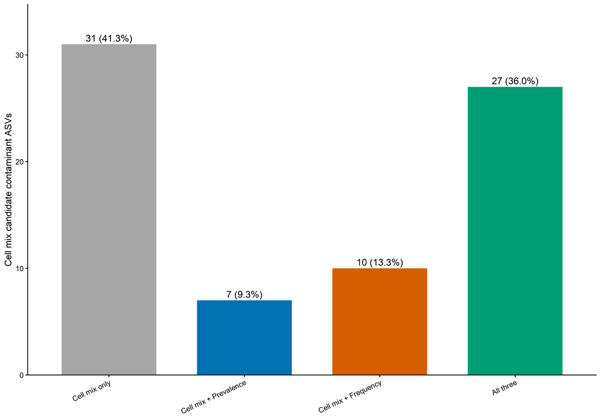

```r
cell_overlap_plot <- ggplot(
  cell_overlap_summary,
  aes(x = overlap_group, y = n_ASVs, fill = overlap_group)
) +
  geom_col(width = 0.7, show.legend = FALSE) +
  geom_text(
    aes(
      label = paste0(
        n_ASVs,
        " (",
        sprintf("%.1f", percent_of_cell_candidates),
        "%)"
      )
    ),
    vjust = -0.4,
    size = 4
  ) +
  scale_fill_manual(values = c(
    "Cell mix only" = "grey65",
    "Cell mix + Prevalence" = "#0072B2",
    "Cell mix + Frequency" = "#D55E00",
    "All three" = "#009E73"
  )) +
  scale_y_continuous(
    expand = expansion(mult = c(0, 0.12))
  ) +
  labs(
    x = NULL,
    y = "Cell mix candidate contaminant ASVs"
  ) +
  theme_classic() +
  theme(
    axis.text.x = element_text(angle = 25, hjust = 1)
  )

ggsave(
  file.path(results_dir, "04_cell_mix_decontam_overlap.png"),
  cell_overlap_plot,
  width = 10,
  height = 7,
  dpi = 300
)

cell_overlap_plot
```

## 3.2 Relative abundance of candidate contaminants in True samples

The following analysis compares the mean relative abundance in True samples for each individual method, each pairwise intersection, and the intersection of all three approaches. Pairwise intersections are inclusive and therefore contain ASVs shared by all three methods.

```r
true_sample_ids <- metadata |>
  dplyr::filter(is_true) |>
  dplyr::pull(SampleID)

true_count <- count_table[true_sample_ids, , drop = FALSE]
true_relative_abundance <- sweep(
  true_count,
  1,
  rowSums(true_count),
  "/"
)

asv_true_abundance <- tibble::tibble(
  feature_id = colnames(true_relative_abundance),
  mean_true_relative_abundance = colMeans(true_relative_abundance),
  median_true_relative_abundance = apply(
    true_relative_abundance,
    2,
    median
  ),
  max_true_relative_abundance = apply(
    true_relative_abundance,
    2,
    max
  ),
  true_sample_prevalence = colMeans(true_count > 0),
  total_true_reads = colSums(true_count)
) |>
  dplyr::left_join(taxonomy, by = "feature_id") |>
  dplyr::mutate(
    Phylum = dplyr::if_else(
      is.na(Phylum) | Phylum == "",
      "Unclassified",
      as.character(Phylum)
    ),
    taxon_label = dplyr::case_when(
      !is.na(Species) & Species != "" ~ Species,
      !is.na(Genus) & Genus != "Unclassified" ~ paste0(Genus, " sp."),
      !is.na(Family) & Family != "" ~ paste0(Family, " sp."),
      TRUE ~ "Unclassified"
    )
  )

comparison_set_list <- list(
  "Cell mix" = cell_candidate_asv,
  "Prevalence" = prevalence_05_asv,
  "Frequency" = frequency_05_asv,
  "Cell mix ∩ Prevalence" = intersect(
    cell_candidate_asv,
    prevalence_05_asv
  ),
  "Cell mix ∩ Frequency" = intersect(
    cell_candidate_asv,
    frequency_05_asv
  ),
  "Prevalence ∩ Frequency" = intersect(
    prevalence_05_asv,
    frequency_05_asv
  ),
  "All three" = Reduce(
    intersect,
    list(cell_candidate_asv, prevalence_05_asv, frequency_05_asv)
  )
)

comparison_set_order <- names(comparison_set_list)
set_abundance_list <- vector("list", length(comparison_set_list))
set_taxa_list <- vector("list", length(comparison_set_list))

for (i in seq_along(comparison_set_list)) {
  set_name <- names(comparison_set_list)[i]
  set_asv <- comparison_set_list[[i]]

  set_asv_abundance <- asv_true_abundance |>
    dplyr::filter(feature_id %in% set_asv)

  set_abundance_list[[i]] <- tibble::tibble(
    comparison_set = set_name,
    n_flagged_ASVs = length(set_asv),
    n_detected_ASVs_in_true = sum(set_asv_abundance$total_true_reads > 0),
    n_major_ASVs_in_true = sum(
      set_asv_abundance$mean_true_relative_abundance >= 0.001
    ),
    mean_total_relative_abundance = sum(
      set_asv_abundance$mean_true_relative_abundance
    ),
    median_total_relative_abundance = median(
      rowSums(
        true_relative_abundance[, set_asv, drop = FALSE]
      )
    )
  )

  set_taxa_list[[i]] <- set_asv_abundance |>
    dplyr::group_by(Phylum, taxon_label) |>
    dplyr::summarise(
      mean_true_relative_abundance = sum(mean_true_relative_abundance),
      n_ASVs = dplyr::n(),
      .groups = "drop"
    ) |>
    dplyr::mutate(comparison_set = set_name, .before = 1)
}

set_true_abundance_summary <- dplyr::bind_rows(set_abundance_list) |>
  dplyr::mutate(
    comparison_set = factor(
      comparison_set,
      levels = comparison_set_order
    )
  )

set_taxa_composition <- dplyr::bind_rows(set_taxa_list) |>
  dplyr::mutate(
    comparison_set = factor(
      comparison_set,
      levels = comparison_set_order
    )
  )

top_true_taxa <- set_taxa_composition |>
  dplyr::filter(comparison_set %in% c("Cell mix", "Prevalence", "Frequency")) |>
  dplyr::group_by(Phylum, taxon_label) |>
  dplyr::summarise(
    maximum_mean_abundance = max(mean_true_relative_abundance),
    .groups = "drop"
  ) |>
  dplyr::slice_max(
    maximum_mean_abundance,
    n = 15,
    with_ties = FALSE
  )

set_taxa_plot_data <- set_taxa_composition |>
  dplyr::mutate(
    Taxon_plot = dplyr::if_else(
      taxon_label %in% top_true_taxa$taxon_label,
      taxon_label,
      "Other"
    ),
    Phylum_plot = dplyr::if_else(
      Taxon_plot == "Other",
      "Other",
      Phylum
    )
  ) |>
  dplyr::group_by(comparison_set, Phylum = Phylum_plot, Taxon_plot) |>
  dplyr::summarise(
    mean_true_relative_abundance = sum(mean_true_relative_abundance),
    .groups = "drop"
  )

taxa_color_input <- set_taxa_plot_data |>
  dplyr::filter(Taxon_plot != "Other") |>
  dplyr::group_by(Phylum, Taxon_plot) |>
  dplyr::summarise(
    sum.Abundance = sum(mean_true_relative_abundance),
    .groups = "drop"
  ) |>
  dplyr::arrange(dplyr::desc(sum.Abundance)) |>
  dplyr::arrange(Phylum)

# functions.R의 taxa_plot과 동일하게 Phylum별 RColorBrewer 계열을 사용한다.
taxa_color <- character()

for (phylum_name in unique(taxa_color_input$Phylum)) {
  phylum_taxa <- taxa_color_input |>
    dplyr::filter(Phylum == phylum_name)

  palette_name <- dplyr::case_when(
    grepl("^(Actinobacteria|Actinobacteriota|Actinomycetota)", phylum_name) ~ "Reds",
    grepl("^(Firmicutes|Bacillota)", phylum_name) ~ "Blues",
    grepl("^(Bacteroidetes|Bacteroidota)", phylum_name) ~ "Purples",
    grepl("^(Proteobacteria|Pseudomonadota)", phylum_name) ~ "Greens",
    grepl("^(Fusobacteria|Fusobacteriota)", phylum_name) ~ "YlOrBr",
    grepl("^Ascomycota", phylum_name) ~ "RdPu",
    grepl("^Basidiomycota", phylum_name) ~ "YlOrBr",
    TRUE ~ "Spectral"
  )

  n_phylum_taxa <- nrow(phylum_taxa)

  if (n_phylum_taxa == 1) {
    phylum_color <- rev(
      RColorBrewer::brewer.pal(9, palette_name)
    )[5]
  } else if (n_phylum_taxa == 2) {
    phylum_color <- rev(
      RColorBrewer::brewer.pal(9, palette_name)
    )[c(3, 7)]
  } else if (n_phylum_taxa <= 9) {
    phylum_color <- rev(
      RColorBrewer::brewer.pal(n_phylum_taxa, palette_name)
    )
  } else {
    phylum_color <- grDevices::colorRampPalette(
      rev(RColorBrewer::brewer.pal(9, palette_name))
    )(n_phylum_taxa)
  }

  names(phylum_color) <- phylum_taxa$Taxon_plot
  taxa_color <- c(taxa_color, phylum_color)
}

taxa_color <- c(taxa_color, Other = "#D3D3D3")
taxa_color <- taxa_color[!duplicated(names(taxa_color))]
taxon_levels <- names(taxa_color)

set_taxa_plot_data <- set_taxa_plot_data |>
  dplyr::mutate(
    Taxon_plot = factor(
      Taxon_plot,
      levels = taxon_levels
    )
  )

contaminant_asv_true_abundance <- asv_true_abundance |>
  dplyr::filter(feature_id %in% all_candidate_asv) |>
  dplyr::left_join(
    three_way_overlap_asv |>
      dplyr::select(feature_id, membership),
    by = "feature_id"
  ) |>
  dplyr::mutate(
    ASV_label = paste0(taxon_label, " | ", substr(feature_id, 1, 8))
  ) |>
  dplyr::arrange(dplyr::desc(mean_true_relative_abundance))

readr::write_csv(
  set_true_abundance_summary,
  file.path(results_dir, "04_contaminant_set_true_abundance_summary.csv")
)
readr::write_csv(
  set_taxa_composition,
  file.path(results_dir, "04_contaminant_taxa_true_composition.csv")
)
readr::write_csv(
  contaminant_asv_true_abundance,
  file.path(results_dir, "04_contaminant_ASV_true_abundance.csv")
)

set_true_abundance_summary |>
  dplyr::mutate(
    mean_total_relative_abundance = 100 * mean_total_relative_abundance,
    median_total_relative_abundance = 100 * median_total_relative_abundance
  ) |>
  knitr::kable(
    digits = 3,
    col.names = c(
      "Contaminant set",
      "Flagged ASVs",
      "Detected ASVs in True",
      "Major ASVs in True",
      "Mean relative abundance (%)",
      "Median relative abundance (%)"
    )
  )
```

| Contaminant set | Flagged ASVs | Detected ASVs in True | Major ASVs in True | Mean relative abundance (%) | Median relative abundance (%) |
| --- | --- | --- | --- | --- | --- |
| Cell mix | 75 | 51 | 9 | 5.841 | 2.806 |
| Prevalence | 379 | 361 | 43 | 42.114 | 41.086 |
| Frequency | 731 | 723 | 66 | 36.441 | 32.933 |
| Cell mix ∩ Prevalence | 34 | 34 | 9 | 5.690 | 2.740 |
| Cell mix ∩ Frequency | 37 | 37 | 8 | 4.519 | 1.601 |
| Prevalence ∩ Frequency | 252 | 244 | 34 | 20.594 | 11.713 |
| All three | 27 | 27 | 8 | 4.411 | 1.566 |

```r
true_taxa_composition_plot <- ggplot(
  set_taxa_plot_data,
  aes(
    x = comparison_set,
    y = mean_true_relative_abundance,
    fill = Taxon_plot
  )
) +
  geom_col(width = 0.75) +
  scale_fill_manual(values = taxa_color) +
  scale_y_continuous(
    labels = scales::label_percent(accuracy = 0.1),
    expand = c(0, 0)
  ) +
  labs(
    x = NULL,
    y = "Mean relative abundance in True samples",
    fill = "Taxon"
  ) +
  theme_classic() +
  theme(
    axis.text.x = element_text(angle = 35, hjust = 1),
    legend.position = "right"
  )

ggsave(
  file.path(results_dir, "04_contaminant_taxa_true_composition.png"),
  true_taxa_composition_plot,
  width = 15,
  height = 8,
  dpi = 300
)

true_taxa_composition_plot
```

[figure not shown]

```r
major_contaminant_asv <- contaminant_asv_true_abundance |>
  dplyr::slice_max(
    mean_true_relative_abundance,
    n = 30,
    with_ties = FALSE
  ) |>
  dplyr::mutate(
    ASV_label = factor(
      ASV_label,
      levels = rev(ASV_label)
    )
  )

major_contaminant_asv_plot <- ggplot(
  major_contaminant_asv,
  aes(
    x = mean_true_relative_abundance,
    y = ASV_label,
    color = membership,
    size = true_sample_prevalence
  )
) +
  geom_point(alpha = 0.85) +
  scale_x_continuous(labels = scales::label_percent(accuracy = 0.01)) +
  scale_size_continuous(labels = scales::label_percent()) +
  scale_color_manual(values = c(
    "Cell mix only" = "grey60",
    "Prevalence only" = "#0072B2",
    "Frequency only" = "#D55E00",
    "Cell mix + Prevalence" = "#56B4E9",
    "Cell mix + Frequency" = "#E69F00",
    "Prevalence + Frequency" = "#CC79A7",
    "All three" = "#009E73"
  )) +
  labs(
    x = "Mean relative abundance in True samples",
    y = NULL,
    color = "Detection evidence",
    size = "True sample prevalence"
  ) +
  theme_classic() +
  theme(legend.position = "right")

ggsave(
  file.path(results_dir, "04_major_contaminant_ASV_in_true_samples.png"),
  major_contaminant_asv_plot,
  width = 13,
  height = 10,
  dpi = 300
)

major_contaminant_asv_plot
```

[figure not shown]

# 4 4) Genus composition across methods and thresholds

Batch aware contaminant ASVs identified from True samples and Prep controls are applied to every sample for visualization. Positive controls and Air Swabs are displayed but are not used to train the contaminant classification.

```r
taxonomy_plot_grid <- tidyr::crossing(
  method = c("prevalence", "frequency"),
  threshold = c(0.1, 0.3, 0.5)
) |>
  dplyr::mutate(
    method_definition = unname(method_label[method]),
    threshold_label = factor(
      paste0("Threshold ", threshold),
      levels = paste0("Threshold ", c(0.1, 0.3, 0.5))
    )
  )

genus_long_list <- vector("list", nrow(taxonomy_plot_grid))

for (i in seq_len(nrow(taxonomy_plot_grid))) {
  setting <- taxonomy_plot_grid[i, ]

  removed_asv <- batch_flagged_asv |>
    dplyr::filter(
      batch_mode == "cycle_batch",
      control_scenario == "prep_control_only",
      method == setting$method,
      dplyr::near(threshold, setting$threshold)
    ) |>
    dplyr::pull(feature_id) |>
    unique()

  filtered_count <- count_table
  filtered_count[, colnames(filtered_count) %in% removed_asv] <- 0

  genus_long_list[[i]] <- as.data.frame(
    filtered_count,
    check.names = FALSE
  ) |>
    tibble::rownames_to_column("SampleID") |>
    tidyr::pivot_longer(
      cols = -SampleID,
      names_to = "feature_id",
      values_to = "read_count"
    ) |>
    dplyr::filter(read_count > 0) |>
    dplyr::left_join(
      taxonomy |>
        dplyr::select(feature_id, Phylum, Genus),
      by = "feature_id"
    ) |>
    dplyr::mutate(
      Phylum = dplyr::if_else(
        is.na(Phylum) | Phylum == "",
        "Unclassified",
        as.character(Phylum)
      ),
      Genus = dplyr::if_else(
        is.na(Genus) | Genus == "",
        "Unclassified",
        as.character(Genus)
      )
    ) |>
    dplyr::group_by(SampleID, Phylum, Genus) |>
    dplyr::summarise(
      read_count = sum(read_count),
      .groups = "drop"
    ) |>
    dplyr::mutate(
      method = setting$method,
      method_definition = setting$method_definition,
      threshold = setting$threshold,
      threshold_label = setting$threshold_label,
      .before = 1
    )
}

all_sample_genus_long <- dplyr::bind_rows(genus_long_list)

sample_plot_metadata <- metadata |>
  dplyr::mutate(
    sample_group = dplyr::case_when(
      is_true ~ "True",
      Sample_Control == "NC" & control_type == "Prep control" ~ "NC | Prep control",
      Sample_Control == "NC" & control_type == "Air Swab" ~ "NC | Air Swab",
      Sample_Control == "PC" & control_type == "Cell_mix" ~ "PC | Cell mix",
      Sample_Control == "PC" & control_type == "DNA_mix" ~ "PC | DNA mix",
      TRUE ~ "Other"
    ),
    sample_group = factor(
      sample_group,
      levels = c(
        "True",
        "NC | Prep control",
        "NC | Air Swab",
        "PC | Cell mix",
        "PC | DNA mix",
        "Other"
      )
    ),
    sample_number = suppressWarnings(as.numeric(No))
  ) |>
  dplyr::arrange(sample_group, Cycle, sample_number)

sample_id_levels <- sample_plot_metadata$SampleID

top_genus_key <- all_sample_genus_long |>
  dplyr::mutate(Genus_key = paste0(Phylum, "_", Genus)) |>
  dplyr::group_by(Phylum, Genus_key) |>
  dplyr::summarise(
    total_reads = sum(read_count),
    .groups = "drop"
  ) |>
  dplyr::slice_max(total_reads, n = 20, with_ties = FALSE)

top_phylum <- unique(top_genus_key$Phylum)

all_sample_genus_long <- all_sample_genus_long |>
  dplyr::left_join(
    sample_plot_metadata |>
      dplyr::select(SampleID, sample_group),
    by = "SampleID"
  ) |>
  dplyr::mutate(
    Genus_key = paste0(Phylum, "_", Genus),
    Genus_plot = dplyr::case_when(
      Genus_key %in% top_genus_key$Genus_key ~ Genus_key,
      Phylum %in% top_phylum ~ paste0(Phylum, "_Other"),
      TRUE ~ "Other"
    ),
    Phylum_plot = dplyr::if_else(
      Genus_plot == "Other",
      "Other",
      Phylum
    ),
    SampleID = factor(SampleID, levels = sample_id_levels),
    method_definition = factor(
      method_definition,
      levels = c("Prevalence", "Frequency")
    )
  ) |>
  dplyr::group_by(
    method,
    method_definition,
    threshold,
    threshold_label,
    sample_group,
    SampleID,
    Phylum = Phylum_plot,
    Genus_plot
  ) |>
  dplyr::summarise(
    read_count = sum(read_count),
    .groups = "drop"
  ) |>
  dplyr::group_by(method, threshold, SampleID) |>
  dplyr::mutate(
    relative_abundance = read_count / sum(read_count)
  ) |>
  dplyr::ungroup()

genus_color_input <- all_sample_genus_long |>
  dplyr::group_by(Phylum, Genus_plot) |>
  dplyr::summarise(
    sum.Abundance = sum(read_count),
    .groups = "drop"
  ) |>
  dplyr::arrange(dplyr::desc(sum.Abundance)) |>
  dplyr::arrange(Phylum)

# functions.R의 taxa_plot과 같은 Phylum별 palette를 적용한다.
genus_color <- character()

for (phylum_name in unique(genus_color_input$Phylum)) {
  phylum_taxa <- genus_color_input |>
    dplyr::filter(Phylum == phylum_name)

  palette_name <- dplyr::case_when(
    grepl("^(Actinobacteria|Actinobacteriota|Actinomycetota)", phylum_name) ~ "Reds",
    grepl("^(Firmicutes|Bacillota)", phylum_name) ~ "Blues",
    grepl("^(Bacteroidetes|Bacteroidota)", phylum_name) ~ "Purples",
    grepl("^(Proteobacteria|Pseudomonadota)", phylum_name) ~ "Greens",
    grepl("^(Fusobacteria|Fusobacteriota)", phylum_name) ~ "YlOrBr",
    phylum_name == "Other" ~ "Greys",
    TRUE ~ "Spectral"
  )

  n_phylum_taxa <- nrow(phylum_taxa)

  if (n_phylum_taxa == 1) {
    phylum_color <- rev(
      RColorBrewer::brewer.pal(9, palette_name)
    )[5]
  } else if (n_phylum_taxa == 2) {
    phylum_color <- rev(
      RColorBrewer::brewer.pal(9, palette_name)
    )[c(3, 7)]
  } else if (n_phylum_taxa <= 9) {
    phylum_color <- rev(
      RColorBrewer::brewer.pal(n_phylum_taxa, palette_name)
    )
  } else {
    phylum_color <- grDevices::colorRampPalette(
      rev(RColorBrewer::brewer.pal(9, palette_name))
    )(n_phylum_taxa)
  }

  names(phylum_color) <- phylum_taxa$Genus_plot
  genus_color <- c(genus_color, phylum_color)
}

genus_color <- genus_color[!duplicated(names(genus_color))]
genus_levels <- names(genus_color)

all_sample_genus_long <- all_sample_genus_long |>
  dplyr::mutate(
    Genus_plot = factor(Genus_plot, levels = genus_levels)
  )

readr::write_csv(
  all_sample_genus_long,
  file.path(
    results_dir,
    "04_all_samples_genus_long_threshold_0.1_0.3_0.5.csv"
  )
)
```

```r
all_sample_genus_read_count_plot <- ggplot(
  all_sample_genus_long,
  aes(x = SampleID, y = read_count, fill = Genus_plot)
) +
  geom_col(width = 0.9) +
  ggh4x::facet_grid2(
    rows = vars(sample_group),
    cols = vars(method_definition, threshold_label),
    scales = "free",
    independent = "x"
  ) +
  scale_fill_manual(values = genus_color, drop = FALSE) +
  scale_y_continuous(
    labels = scales::label_comma(),
    expand = c(0, 0)
  ) +
  labs(
    x = NULL,
    y = "Read count after decontamination",
    fill = "Phylum_Genus"
  ) +
  theme_classic() +
  theme(
    axis.text.x = element_text(angle = 90, hjust = 1, vjust = 0.5, size = 5),
    strip.background = element_rect(fill = "white", color = "grey50"),
    panel.border = element_rect(color = "black", fill = NA, linewidth = 0.4),
    panel.spacing = grid::unit(3, "mm"),
    legend.position = "right"
  )

ggsave(
  file.path(results_dir, "04_all_samples_genus_read_count.png"),
  all_sample_genus_read_count_plot,
  width = 32,
  height = 18,
  dpi = 300
)

all_sample_genus_read_count_plot
```

[figure not shown]

```r
all_sample_genus_relative_abundance_plot <- ggplot(
  all_sample_genus_long,
  aes(x = SampleID, y = relative_abundance, fill = Genus_plot)
) +
  geom_col(width = 0.9) +
  ggh4x::facet_grid2(
    rows = vars(sample_group),
    cols = vars(method_definition, threshold_label),
    scales = "free_x",
    independent = "x"
  ) +
  scale_fill_manual(values = genus_color, drop = FALSE) +
  scale_y_continuous(
    labels = scales::label_percent(),
    limits = c(0, 1),
    expand = c(0, 0)
  ) +
  labs(
    x = NULL,
    y = "Relative abundance after decontamination",
    fill = "Phylum_Genus"
  ) +
  theme_classic() +
  theme(
    axis.text.x = element_text(angle = 90, hjust = 1, vjust = 0.5, size = 5),
    strip.background = element_rect(fill = "white", color = "grey50"),
    panel.border = element_rect(color = "black", fill = NA, linewidth = 0.4),
    panel.spacing = grid::unit(3, "mm"),
    legend.position = "right"
  )

ggsave(
  file.path(results_dir, "04_all_samples_genus_relative_abundance.png"),
  all_sample_genus_relative_abundance_plot,
  width = 32,
  height = 18,
  dpi = 300
)

all_sample_genus_relative_abundance_plot
```

[figure not shown]

# 5 5) Cycle 3 decontam analysis using Prep controls

```r
# Positive control은 contaminant 판정에서 제외하고 검증에만 사용한다.
cycle3_balance <- metadata |>
  dplyr::filter(Cycle == "3") |>
  dplyr::mutate(
    sample_role = dplyr::case_when(
      is_true ~ "True",
      is_prep_control ~ "Prep control",
      is_air_swab ~ "Air Swab",
      is_cell_mock ~ "Cell mock",
      TRUE ~ "Other"
    )
  ) |>
  dplyr::count(sample_role, name = "n_samples")

knitr::kable(cycle3_balance)
```

| sample_role | n_samples |
| --- | --- |
| Air Swab | 1 |
| Cell mock | 3 |
| Prep control | 3 |
| True | 17 |

```r
# Cell mix와 동일한 DNA 추출 Cycle 3의 Prep control로 contaminant ASV를 판정한다.
run_cycle3_decontam <- function(control_scenario, method) {
  meta <- data.frame(sample_data(phy), check.names = FALSE)

  selected_control <- switch(
    control_scenario,
    prep_control_only = meta$is_prep_control,
    air_swab_only = meta$is_air_swab,
    prep_and_air_swab = meta$is_prep_control | meta$is_air_swab
  )

  keep_sample <- meta$Cycle == "3" & (meta$is_true | selected_control)
  run_phy <- prune_samples(keep_sample, phy)
  run_phy <- prune_taxa(taxa_sums(run_phy) > 0, run_phy)

  run_meta <- data.frame(sample_data(run_phy), check.names = FALSE)
  run_meta$decontam_group <- ifelse(
    run_meta$is_prep_control | run_meta$is_air_swab,
    "control",
    "biological"
  )
  sample_data(run_phy) <- sample_data(run_meta)

  argument <- list(
    ps = run_phy,
    control_column = "decontam_group",
    control_label = "control",
    thresholds = thresholds,
    method = method
  )

  if (method == "frequency") {
    argument$concentration_column <- "decontam_concentration"
  }

  list(
    control_scenario = control_scenario,
    method = method,
    result = do.call(
      decontamSensitivity::run_decontam_threshold_sweep,
      argument
    )
  )
}
```

```r
analysis_grid <- tidyr::crossing(
  control_scenario = control_scenarios,
  method = methods
) |>
  dplyr::mutate(
    run_id = paste(control_scenario, method, sep = "__")
  )

cache_path <- file.path(results_dir, "04_cycle3_decontam_runs.rds")
cache_config <- list(
  input_md5 = unname(tools::md5sum(input_path)),
  thresholds = thresholds,
  methods = methods,
  control_scenarios = control_scenarios
)

use_cache <- FALSE
if (file.exists(cache_path) && !isTRUE(params$force_recompute)) {
  cached <- readRDS(cache_path)
  use_cache <- identical(cached$config, cache_config)
}

if (use_cache) {
  cycle3_runs <- cached$runs
} else {
  cycle3_runs <- vector("list", nrow(analysis_grid))
  names(cycle3_runs) <- analysis_grid$run_id

  for (i in seq_len(nrow(analysis_grid))) {
    run_info <- analysis_grid[i, ]
    cycle3_runs[[run_info$run_id]] <- run_cycle3_decontam(
      control_scenario = run_info$control_scenario,
      method = run_info$method
    )
  }

  saveRDS(
    list(config = cache_config, runs = cycle3_runs),
    cache_path
  )
}

analysis_grid |>
  dplyr::mutate(cache_used = use_cache) |>
  knitr::kable()
```

| control_scenario | method | run_id | cache_used |
| --- | --- | --- | --- |
| prep_control_only | frequency | prep_control_only__frequency | TRUE |
| prep_control_only | prevalence | prep_control_only__prevalence | TRUE |

```r
flag_list <- vector("list", length(cycle3_runs))

for (i in seq_along(cycle3_runs)) {
  run <- cycle3_runs[[i]]

  flag_list[[i]] <- run$result$feature_flags |>
    dplyr::filter(contaminant) |>
    dplyr::mutate(
      control_scenario = run$control_scenario,
      control_definition = unname(scenario_label[run$control_scenario]),
      method = run$method,
      method_definition = unname(method_label[run$method]),
      .before = 1
    )
}

cycle3_flags <- dplyr::bind_rows(flag_list) |>
  dplyr::arrange(control_scenario, method, threshold, feature_id)

readr::write_csv(
  cycle3_flags,
  file.path(results_dir, "04_cycle3_flagged_ASV.csv")
)
```

# 6 6) Cell and DNA mock profiles after decontamination

```r
# 같은 contaminant ASV 목록을 Cell mix와 DNA mix에 적용한다.
mock_sample_ids <- c(cell_mock_ids, dna_mock_id)

profile_list <- vector(
  "list",
  nrow(analysis_grid) * length(thresholds) * length(mock_sample_ids)
)
profile_index <- 1

for (run_id in names(cycle3_runs)) {
  run <- cycle3_runs[[run_id]]

  for (threshold_value in thresholds) {
    removed_asv <- cycle3_flags |>
      dplyr::filter(
        control_scenario == run$control_scenario,
        method == run$method,
        threshold == threshold_value
      ) |>
      dplyr::pull(feature_id)

    for (sample_id in mock_sample_ids) {
      profile_list[[profile_index]] <- make_genus_profile(
        sample_id,
        removed_asv
      ) |>
        dplyr::mutate(
          mock_type = dplyr::if_else(
            sample_id %in% cell_mock_ids,
            "Cell mix",
            "DNA mix"
          ),
          control_scenario = run$control_scenario,
          control_definition = unname(scenario_label[run$control_scenario]),
          method = run$method,
          method_definition = unname(method_label[run$method]),
          threshold = round(threshold_value, 2),
          removed_ASVs = length(removed_asv),
          .before = 1
        )

      profile_index <- profile_index + 1
    }
  }
}

filtered_mock_profile <- dplyr::bind_rows(profile_list)

# 정확도 평가는 기존과 동일하게 Cell mix 반복 시료를 사용한다.
filtered_cell_profile <- filtered_mock_profile |>
  dplyr::filter(mock_type == "Cell mix")

readr::write_csv(
  filtered_mock_profile,
  file.path(results_dir, "04_filtered_cell_and_dna_mock_genus_profile.csv")
)
readr::write_csv(
  filtered_cell_profile,
  file.path(results_dir, "04_filtered_cell_mock_genus_profile.csv")
)
```

## 6.1 Cell mix and DNA mix composition across thresholds 0.1 to 0.9

```r
# 서로 다른 희석 조건인 Cell mix 3개와 DNA mix를 각각 표시한다.
mock_axis_label <- metadata |>
  dplyr::filter(SampleID %in% mock_sample_ids) |>
  dplyr::select(SampleID, Subject) |>
  dplyr::mutate(
    mock_sample = factor(
      Subject,
      levels = Subject[match(mock_sample_ids, SampleID)]
    )
  )

composition_01_09 <- filtered_mock_profile |>
  dplyr::filter(threshold >= 0.1, threshold <= 0.9) |>
  dplyr::left_join(mock_axis_label, by = "SampleID") |>
  dplyr::mutate(
    Genus_plot = dplyr::if_else(Genus %in% target_genera, Genus, "Other")
  ) |>
  dplyr::group_by(
    control_definition,
    method_definition,
    threshold,
    mock_sample,
    Genus_plot
  ) |>
  dplyr::summarise(
    relative_abundance = sum(relative_abundance),
    .groups = "drop"
  ) |>
  dplyr::mutate(
    threshold_label = factor(
      paste0("Threshold ", sprintf("%.1f", threshold)),
      levels = paste0("Threshold ", sprintf("%.1f", seq(0.1, 0.9, by = 0.1)))
    )
  )

composition_01_09_plot <- ggplot(
  composition_01_09,
  aes(x = mock_sample, y = relative_abundance, fill = Genus_plot)
) +
  geom_col(width = 0.8) +
  facet_grid(
    method_definition + control_definition ~ threshold_label
  ) +
  scale_fill_manual(values = mock_taxa_color) +
  scale_y_continuous(labels = scales::label_percent(), expand = c(0, 0)) +
  labs(
    x = NULL,
    y = "Relative abundance after decontamination",
    fill = "Genus"
  ) +
  theme_classic() +
  theme(
    axis.text.x = element_text(angle = 45, hjust = 1, size = 8),
    strip.background = element_rect(fill = "white", color = "grey50"),
    panel.border = element_rect(color = "black", fill = NA, linewidth = 0.6),
    panel.spacing = grid::unit(4, "mm"),
    legend.position = "right"
  )

ggsave(
  file.path(results_dir, "04_cell_and_dna_mock_composition_threshold_0.1_0.9.png"),
  composition_01_09_plot,
  width = 36,
  height = 20,
  dpi = 300
)

readr::write_csv(
  composition_01_09,
  file.path(results_dir, "04_cell_and_dna_mock_composition_threshold_0.1_0.9.csv")
)

composition_01_09_plot
```

[figure not shown]

# 7 7) Accuracy metrics

DNA mix is included only in the composition plots. Detection metrics and Bray Curtis distance are calculated using the three Cell mix replicates. The observed DNA mix composition is retained only as a reference profile for evaluating the Cell mix samples.

The accuracy metrics follow the ITS2 mock benchmark: detection based F1 score, precision, recall and false discovery rate, together with abundance based R squared and Bray Curtis distance. Higher F1 and R squared and lower Bray Curtis distance indicate closer agreement with the reference.

```r
# 각 profile을 theoretical composition과 DNA mock에 반복 비교한다.
calculate_accuracy <- function(profile_df, expected_df, reference_name) {
  genus_universe <- union(profile_df$Genus, expected_df$Genus)

  observed <- profile_df$relative_abundance[match(genus_universe, profile_df$Genus)]
  expected <- expected_df$expected_abundance[match(genus_universe, expected_df$Genus)]
  observed[is.na(observed)] <- 0
  expected[is.na(expected)] <- 0

  detected <- observed > 0
  expected_detected <- expected > 0
  TP <- sum(detected & expected_detected)
  FP <- sum(detected & !expected_detected)
  FN <- sum(!detected & expected_detected)

  precision <- ifelse(TP + FP > 0, TP / (TP + FP), NA_real_)
  recall <- ifelse(TP + FN > 0, TP / (TP + FN), NA_real_)
  F1 <- ifelse(
    !is.na(precision) & !is.na(recall) & precision + recall > 0,
    2 * precision * recall / (precision + recall),
    NA_real_
  )

  tibble::tibble(
    reference = reference_name,
    TP = TP,
    FP = FP,
    FN = FN,
    precision = precision,
    recall = recall,
    F1 = F1,
    false_discovery_rate = ifelse(TP + FP > 0, FP / (TP + FP), NA_real_),
    R2 = ifelse(
      sd(observed) > 0 & sd(expected) > 0,
      cor(observed, expected)^2,
      NA_real_
    ),
    Bray_Curtis = as.numeric(
      vegan::vegdist(rbind(observed, expected), method = "bray")[1]
    ),
    target_abundance = sum(observed[genus_universe %in% target_genera]),
    off_target_abundance = sum(observed[!genus_universe %in% target_genera])
  )
}
```

```r
theoretical_reference <- mock_truth |>
  dplyr::select(Genus, expected_abundance)

dna_reference <- dna_mock_profile |>
  dplyr::rename(expected_abundance = dna_mock_abundance)

profile_setting <- filtered_cell_profile |>
  dplyr::distinct(
    control_scenario,
    control_definition,
    method,
    method_definition,
    threshold,
    SampleID
  )

accuracy_list <- vector("list", nrow(profile_setting) * 2)
accuracy_index <- 1

for (i in seq_len(nrow(profile_setting))) {
  setting <- profile_setting[i, ]

  profile_i <- filtered_cell_profile |>
    dplyr::filter(
      control_scenario == setting$control_scenario,
      method == setting$method,
      threshold == setting$threshold,
      SampleID == setting$SampleID
    ) |>
    dplyr::select(Genus, relative_abundance)

  accuracy_list[[accuracy_index]] <- calculate_accuracy(
    profile_i,
    theoretical_reference,
    "MSA-2005 theoretical"
  ) |>
    dplyr::bind_cols(setting)
  accuracy_index <- accuracy_index + 1

  accuracy_list[[accuracy_index]] <- calculate_accuracy(
    profile_i,
    dna_reference,
    "DNA mock observed"
  ) |>
    dplyr::bind_cols(setting)
  accuracy_index <- accuracy_index + 1
}

accuracy_metrics <- dplyr::bind_rows(accuracy_list) |>
  dplyr::select(
    control_scenario,
    control_definition,
    method,
    method_definition,
    threshold,
    SampleID,
    dplyr::everything()
  )

# 제거 전 Cell mock의 정확도를 baseline으로 계산한다.
raw_accuracy_list <- vector("list", length(cell_mock_ids) * 2)
raw_accuracy_index <- 1

for (sample_id in cell_mock_ids) {
  raw_profile_i <- raw_cell_profile |>
    dplyr::filter(SampleID == sample_id) |>
    dplyr::select(Genus, relative_abundance)

  raw_accuracy_list[[raw_accuracy_index]] <- calculate_accuracy(
    raw_profile_i,
    theoretical_reference,
    "MSA-2005 theoretical"
  ) |>
    dplyr::mutate(SampleID = sample_id)
  raw_accuracy_index <- raw_accuracy_index + 1

  raw_accuracy_list[[raw_accuracy_index]] <- calculate_accuracy(
    raw_profile_i,
    dna_reference,
    "DNA mock observed"
  ) |>
    dplyr::mutate(SampleID = sample_id)
  raw_accuracy_index <- raw_accuracy_index + 1
}

raw_accuracy_metrics <- dplyr::bind_rows(raw_accuracy_list)

raw_accuracy_summary <- raw_accuracy_metrics |>
  dplyr::group_by(reference) |>
  dplyr::summarise(
    dplyr::across(
      c(
        precision,
        recall,
        F1,
        false_discovery_rate,
        R2,
        Bray_Curtis,
        target_abundance,
        off_target_abundance
      ),
      ~ mean(.x, na.rm = TRUE),
      .names = "{.col}_raw"
    ),
    .groups = "drop"
  )

accuracy_summary <- accuracy_metrics |>
  dplyr::group_by(
    reference,
    control_scenario,
    control_definition,
    method,
    method_definition,
    threshold
  ) |>
  dplyr::summarise(
    dplyr::across(
      c(
        precision,
        recall,
        F1,
        false_discovery_rate,
        R2,
        Bray_Curtis,
        target_abundance,
        off_target_abundance
      ),
      list(mean = ~ mean(.x, na.rm = TRUE), se = ~ sd(.x, na.rm = TRUE) / sqrt(dplyr::n())),
      .names = "{.col}_{.fn}"
    ),
    .groups = "drop"
  )

readr::write_csv(
  accuracy_metrics,
  file.path(results_dir, "04_mock_accuracy_by_sample.csv")
)
readr::write_csv(
  accuracy_summary,
  file.path(results_dir, "04_mock_accuracy_summary.csv")
)
readr::write_csv(
  raw_accuracy_metrics,
  file.path(results_dir, "04_raw_mock_accuracy_by_sample.csv")
)
readr::write_csv(
  raw_accuracy_summary,
  file.path(results_dir, "04_raw_mock_accuracy_summary.csv")
)
```

## 7.1 Main accuracy metrics

```r
main_metric_plot_data <- accuracy_summary |>
  dplyr::select(
    reference,
    control_definition,
    method_definition,
    threshold,
    F1_mean,
    R2_mean,
    Bray_Curtis_mean
  ) |>
  tidyr::pivot_longer(
    cols = c(F1_mean, R2_mean, Bray_Curtis_mean),
    names_to = "metric",
    values_to = "value"
  ) |>
  dplyr::mutate(
    metric = dplyr::recode(
      metric,
      F1_mean = "F1 score",
      R2_mean = "R squared",
      Bray_Curtis_mean = "Bray Curtis distance"
    ),
    metric = factor(
      metric,
      levels = c("F1 score", "R squared", "Bray Curtis distance")
    )
  )

raw_main_plot_data <- raw_accuracy_summary |>
  dplyr::select(reference, F1_raw, R2_raw, Bray_Curtis_raw) |>
  tidyr::pivot_longer(
    cols = c(F1_raw, R2_raw, Bray_Curtis_raw),
    names_to = "metric",
    values_to = "value"
  ) |>
  dplyr::mutate(
    metric = dplyr::recode(
      metric,
      F1_raw = "F1 score",
      R2_raw = "R squared",
      Bray_Curtis_raw = "Bray Curtis distance"
    ),
    metric = factor(
      metric,
      levels = c("F1 score", "R squared", "Bray Curtis distance")
    )
  )

main_accuracy_plot <- ggplot(
  main_metric_plot_data,
  aes(x = threshold, y = value, color = method_definition)
) +
  geom_hline(
    data = raw_main_plot_data,
    aes(yintercept = value),
    inherit.aes = FALSE,
    linetype = 2,
    color = "grey35",
    linewidth = 0.6
  ) +
  geom_line(linewidth = 0.7) +
  geom_point(size = 2) +
  facet_grid(
    reference + metric ~ control_definition,
    scales = "free_y"
  ) +
  scale_color_manual(values = c(
    "Prevalence" = "#0072B2",
    "Frequency" = "#D55E00"
  )) +
  scale_x_continuous(breaks = thresholds) +
  labs(x = "Threshold", y = "Accuracy metric", color = "Method") +
  theme_classic() +
  theme(
    axis.text.x = element_text(angle = 45, hjust = 1),
    strip.background = element_rect(fill = "white", color = "grey50"),
    panel.border = element_rect(color = "black", fill = NA, linewidth = 0.6),
    panel.spacing = grid::unit(4, "mm"),
    legend.position = "top"
  )

ggsave(
  file.path(results_dir, "04_mock_accuracy_main_metrics.png"),
  main_accuracy_plot,
  width = 15,
  height = 11,
  dpi = 300
)

main_accuracy_plot
```

[figure not shown]

## 7.2 Detection metrics

```r
detection_plot_data <- accuracy_summary |>
  dplyr::select(
    reference,
    control_definition,
    method_definition,
    threshold,
    precision_mean,
    recall_mean,
    false_discovery_rate_mean
  ) |>
  tidyr::pivot_longer(
    cols = c(precision_mean, recall_mean, false_discovery_rate_mean),
    names_to = "metric",
    values_to = "value"
  ) |>
  dplyr::mutate(
    metric = dplyr::recode(
      metric,
      precision_mean = "Precision",
      recall_mean = "Recall",
      false_discovery_rate_mean = "False discovery rate"
    )
  )

raw_detection_plot_data <- raw_accuracy_summary |>
  dplyr::select(
    reference,
    precision_raw,
    recall_raw,
    false_discovery_rate_raw
  ) |>
  tidyr::pivot_longer(
    cols = c(precision_raw, recall_raw, false_discovery_rate_raw),
    names_to = "metric",
    values_to = "value"
  ) |>
  dplyr::mutate(
    metric = dplyr::recode(
      metric,
      precision_raw = "Precision",
      recall_raw = "Recall",
      false_discovery_rate_raw = "False discovery rate"
    )
  )

detection_metric_plot <- ggplot(
  detection_plot_data,
  aes(x = threshold, y = value, color = method_definition)
) +
  geom_hline(
    data = raw_detection_plot_data,
    aes(yintercept = value),
    inherit.aes = FALSE,
    linetype = 2,
    color = "grey35",
    linewidth = 0.6
  ) +
  geom_line(linewidth = 0.7) +
  geom_point(size = 2) +
  facet_grid(
    reference + metric ~ control_definition,
    scales = "free_y"
  ) +
  scale_color_manual(values = c(
    "Prevalence" = "#0072B2",
    "Frequency" = "#D55E00"
  )) +
  scale_x_continuous(breaks = thresholds) +
  scale_y_continuous(limits = c(0, 1)) +
  labs(x = "Threshold", y = "Detection metric", color = "Method") +
  theme_classic() +
  theme(
    axis.text.x = element_text(angle = 45, hjust = 1),
    strip.background = element_rect(fill = "white", color = "grey50"),
    panel.border = element_rect(color = "black", fill = NA, linewidth = 0.6),
    panel.spacing = grid::unit(4, "mm"),
    legend.position = "top"
  )

ggsave(
  file.path(results_dir, "04_mock_accuracy_detection_metrics.png"),
  detection_metric_plot,
  width = 15,
  height = 10,
  dpi = 300
)

detection_metric_plot
```

[figure not shown]

## 7.3 Best threshold by Bray Curtis distance

```r
# 각 reference에서 평균 Bray Curtis distance가 가장 낮은 조건을 제시한다.
best_threshold <- accuracy_summary |>
  dplyr::group_by(reference, control_definition, method_definition) |>
  dplyr::slice_min(Bray_Curtis_mean, n = 1, with_ties = FALSE) |>
  dplyr::ungroup() |>
  dplyr::select(
    reference,
    control_definition,
    method_definition,
    threshold,
    Bray_Curtis_mean,
    R2_mean,
    F1_mean,
    target_abundance_mean,
    off_target_abundance_mean
  ) |>
  dplyr::left_join(raw_accuracy_summary, by = "reference") |>
  dplyr::mutate(
    Bray_Curtis_improvement = Bray_Curtis_raw - Bray_Curtis_mean,
    R2_improvement = R2_mean - R2_raw,
    F1_improvement = F1_mean - F1_raw
  ) |>
  dplyr::select(
    reference,
    control_definition,
    method_definition,
    threshold,
    Bray_Curtis_mean,
    Bray_Curtis_raw,
    Bray_Curtis_improvement,
    R2_mean,
    R2_raw,
    R2_improvement,
    F1_mean,
    F1_raw,
    F1_improvement,
    target_abundance_mean,
    off_target_abundance_mean
  ) |>
  dplyr::arrange(reference, control_definition, method_definition)

readr::write_csv(
  best_threshold,
  file.path(results_dir, "04_best_threshold_by_reference.csv")
)

knitr::kable(best_threshold, digits = 4)
```

| reference | control_definition | method_definition | threshold | Bray_Curtis_mean | Bray_Curtis_raw | Bray_Curtis_improvement | R2_mean | R2_raw | R2_improvement | F1_mean | F1_raw | F1_improvement | target_abundance_mean | off_target_abundance_mean |
| --- | --- | --- | --- | --- | --- | --- | --- | --- | --- | --- | --- | --- | --- | --- |
| DNA mock observed | Prep control only | Frequency | 0.80 | 0.4283 | 0.5091 | 0.0808 | 0.6178 | 0.5086 | 0.1093 | 0.5189 | 0.6607 | -0.1418 | 0.8138 | 0.1862 |
| DNA mock observed | Prep control only | Prevalence | 0.60 | 0.3771 | 0.5091 | 0.1320 | 0.5619 | 0.5086 | 0.0534 | 0.5469 | 0.6607 | -0.1139 | 0.8540 | 0.1460 |
| MSA-2005 theoretical | Prep control only | Frequency | 0.05 | 0.5967 | 0.5968 | 0.0001 | 0.2850 | 0.2850 | 0.0000 | 0.2198 | 0.2198 | 0.0000 | 0.9313 | 0.0687 |
| MSA-2005 theoretical | Prep control only | Prevalence | 0.60 | 0.5327 | 0.5968 | 0.0641 | 0.4213 | 0.2850 | 0.1363 | 0.1788 | 0.2198 | -0.0410 | 0.8540 | 0.1460 |

## 7.4 Accuracy at threshold 0.5

```r
accuracy_threshold_05 <- accuracy_summary |>
  dplyr::filter(threshold == 0.5) |>
  dplyr::left_join(raw_accuracy_summary, by = "reference") |>
  dplyr::mutate(
    Bray_Curtis_improvement = Bray_Curtis_raw - Bray_Curtis_mean,
    R2_improvement = R2_mean - R2_raw,
    F1_improvement = F1_mean - F1_raw
  ) |>
  dplyr::select(
    reference,
    control_definition,
    method_definition,
    threshold,
    Bray_Curtis_mean,
    Bray_Curtis_raw,
    Bray_Curtis_improvement,
    R2_mean,
    R2_raw,
    R2_improvement,
    F1_mean,
    F1_raw,
    F1_improvement
  ) |>
  dplyr::arrange(reference, control_definition, method_definition)

readr::write_csv(
  accuracy_threshold_05,
  file.path(results_dir, "04_accuracy_threshold_0.5_vs_raw.csv")
)

knitr::kable(accuracy_threshold_05, digits = 4)
```

| reference | control_definition | method_definition | threshold | Bray_Curtis_mean | Bray_Curtis_raw | Bray_Curtis_improvement | R2_mean | R2_raw | R2_improvement | F1_mean | F1_raw | F1_improvement |
| --- | --- | --- | --- | --- | --- | --- | --- | --- | --- | --- | --- | --- |
| DNA mock observed | Prep control only | Frequency | 0.5 | 0.6057 | 0.5091 | -0.0966 | 0.4606 | 0.5086 | -0.0480 | 0.5957 | 0.6607 | -0.0650 |
| DNA mock observed | Prep control only | Prevalence | 0.5 | 0.5093 | 0.5091 | -0.0002 | 0.5168 | 0.5086 | 0.0082 | 0.5679 | 0.6607 | -0.0928 |
| MSA-2005 theoretical | Prep control only | Frequency | 0.5 | 0.6732 | 0.5968 | -0.0764 | 0.2349 | 0.2850 | -0.0501 | 0.2242 | 0.2198 | 0.0045 |
| MSA-2005 theoretical | Prep control only | Prevalence | 0.5 | 0.6711 | 0.5968 | -0.0743 | 0.2350 | 0.2850 | -0.0500 | 0.2245 | 0.2198 | 0.0047 |

The theoretical and DNA mock references answer different questions. Agreement with the theoretical profile evaluates recovery of the nominal equal mixture, whereas agreement with the DNA mock evaluates whether Cell mock processing approaches the composition observed after bypassing cell lysis and DNA extraction. The two results should therefore be reported separately.